# The_Analytics_Edge_edX_MIT15.071x_June2015

```r
#However, none of the interviewees aged 14 and younger have an education value reported, so the mean value is reported as NA for each metropolitan area. To get mean (and related functions, like sum) to ignore missing values, you can pass the parameter na.rm=TRUE. Passing na.rm=TRUE to the tapply function, determine which metropolitan area has the smallest proportion of interviewees who have received no high school diploma.
#Ans:Iowa City, IA
#We can see that Iowa City, IA had 2.9% of interviewees not finish high school, the smallest value of any metropolitan area.

######################################################

#PROBLEM 4.1 - INTEGRATING COUNTRY OF BIRTH DATA

#Just as we did with the metropolitan area information, merge in the country of birth information from the CountryMap data frame, replacing the CPS data frame with the result. If you accidentally overwrite CPS with the wrong values, remember that you can restore it by re-loading the data frame from CPSData.csv and then merging in the metropolitan area information using the command provided in the previous subproblem.
str(CPS)
```

```
## 'data.frame':    131302 obs. of  15 variables:
##  $ MetroAreaCode     : int  10420 10420 10420 10420 10420 10420 10420 10420 10420 10420 ...
##  $ PeopleInHousehold : int  4 4 2 4 1 3 4 4 2 3 ...
##  $ Region            : Factor w/ 4 levels "Midwest","Northeast",..: 1 1 1 1 1 1 1 1 1 1 ...
##  $ State             : Factor w/ 51 levels "Alabama","Alaska",..: 36 36 36 36 36 36 36 36 36 36 ...
##  $ Age               : int  2 9 73 40 63 19 30 6 60 32 ...
##  $ Married           : Factor w/ 5 levels "Divorced","Married",..: NA NA 2 2 3 3 2 NA 2 2 ...
##  $ Sex               : Factor w/ 2 levels "Female","Male": 2 2 1 1 2 1 1 1 1 2 ...
##  $ Education         : Factor w/ 8 levels "Associate degree",..: NA NA 8 4 6 4 2 NA 4 4 ...
##  $ Race              : Factor w/ 6 levels "American Indian",..: 6 6 6 6 6 6 2 6 6 6 ...
##  $ Hispanic          : int  0 0 0 0 0 0 0 1 0 0 ...
##  $ CountryOfBirthCode: int  57 57 57 362 57 57 203 57 57 57 ...
##  $ Citizenship       : Factor w/ 3 levels "Citizen, Native",..: 1 1 1 2 1 1 3 1 1 1 ...
##  $ EmploymentStatus  : Factor w/ 5 levels "Disabled","Employed",..: NA NA 4 3 1 2 3 NA 2 2 ...
##  $ Industry          : Factor w/ 14 levels "Agriculture, forestry, fishing, and hunting",..: NA NA NA NA NA 7 NA NA 4 13 ...
##  $ MetroArea         : Factor w/ 271 levels "Akron, OH","Albany-Schenectady-Troy, NY",..: 1 1 1 1 1 1 1 1 1 1 ...
```

```r
CPS<-merge(CPS, CountryMap, by.x="CountryOfBirthCode", by.y="Code", all.x=TRUE)
summary(CPS)
```

```
##  CountryOfBirthCode MetroAreaCode   PeopleInHousehold       Region
##  Min.   : 57.00     Min.   :10420   Min.   : 1.000    Midwest  :30684
##  1st Qu.: 57.00     1st Qu.:21780   1st Qu.: 2.000    Northeast:25939
##  Median : 57.00     Median :34740   Median : 3.000    South    :41502
##  Mean   : 82.68     Mean   :35075   Mean   : 3.284    West     :33177
##  3rd Qu.: 57.00     3rd Qu.:41860   3rd Qu.: 4.000
##  Max.   :555.00     Max.   :79600   Max.   :15.000
##                     NA's   :34238
##           State            Age                 Married          Sex
##  California  :11570   Min.   : 0.00   Divorced     :11151   Female:67481
##  Texas       : 7077   1st Qu.:19.00   Married      :55509   Male  :63821
##  New York    : 5595   Median :39.00   Never Married:30772
##  Florida     : 5149   Mean   :38.83   Separated    : 2027
##  Pennsylvania: 3930   3rd Qu.:57.00   Widowed      : 6505
##  Illinois    : 3912   Max.   :85.00   NA's         :25338
##  (Other)     :94069
##                    Education                   Race
##  High school            :30906   American Indian :  1433
##  Bachelor's degree      :19443   Asian           :  6520
##  Some college, no degree:18863   Black           : 13913
##  No high school diploma :16095   Multiracial     :  2897
##  Associate degree       : 9913   Pacific Islander:   618
##  (Other)                :10744   White           :105921
##  NA's                   :25338
##     Hispanic                    Citizenship               EmploymentStatus
##  Min.   :0.0000   Citizen, Native     :116639   Disabled          : 5712
##  1st Qu.:0.0000   Citizen, Naturalized:  7073   Employed          :61733
##  Median :0.0000   Non-Citizen         :  7590   Not in Labor Force:15246
##  Mean   :0.1393                                 Retired           :18619
##  3rd Qu.:0.0000                                 Unemployed        : 4203
##  Max.   :1.0000                                 NA's              :25789
##
##                                Industry
##  Educational and health services   :15017
##  Trade                             : 8933
##  Professional and business services: 7519
##  Manufacturing                     : 6791
##  Leisure and hospitality           : 6364
##  (Other)                           :21618
##  NA's                              :65060
##                                               MetroArea
##  New York-Northern New Jersey-Long Island, NY-NJ-PA: 5409
##  Washington-Arlington-Alexandria, DC-VA-MD-WV      : 4177
##  Los Angeles-Long Beach-Santa Ana, CA              : 4102
##  Philadelphia-Camden-Wilmington, PA-NJ-DE          : 2855
##  Chicago-Naperville-Joliet, IN-IN-WI               : 2772
##  (Other)                                           :77749
##  NA's                                              :34238
##           Country
##  United States:115063
##  Mexico       :  3921
##  Philippines  :   839
##  India        :   770
##  China        :   581
##  (Other)      :  9952
##  NA's         :   176
```

```r
#What is the name of the variable added to the CPS data frame by this merge operation?
#Ans:Country

#How many interviewees have a missing value for the new country of birth variable?
#Ans:  176

#Among all interviewees born outside of North America, which country was the most common place of birth?
head(sort(table(CPS$Country),decreasing=T))  #or
```

```
##
## United States        Mexico   Philippines         India         China
##        115063          3921           839           770           581
##   Puerto Rico
##           518
```

```r
head(summary(CPS$Country))
```

```
## United States        Mexico   Philippines         India         China
##        115063          3921           839           770           581
##   Puerto Rico
##           518
```

```r
#Ans:Philippines

#What proportion of the interviewees from the "New York-Northern New Jersey-Long Island, NY-NJ-PA" metropolitan area have a country of birth that is not the United States? For this computation, don't include people from this metropolitan area who have a missing country of birth.'
tapply(CPS$Country!= "United States",CPS$MetroArea == "New York-Northern New Jersey-Long Island, NY-NJ-PA",mean,na.rm=TRUE)
```

```
##     FALSE      TRUE
## 0.1392772 0.3086603
```

```r
#or
table(CPS$MetroArea =="New York-Northern New Jersey-Long Island, NY-NJ-PA", CPS$Country!="United States")
```

```
##
##         FALSE  TRUE
##   FALSE 78757 12744
##   TRUE   3736  1668
```

```r
#Ans:0.3086603
#EXPLANATION:From table(CPS$MetroArea == "New York-Northern New Jersey-Long Island, NY-NJ-PA", CPS$Country != "United States"), we can see that 1668 of interviewees from this metropolitan area were born outside the United States and 3736 were born in the United States (it turns out an additional 5 have a missing country of origin). Therefore, the proportion is 1668/(1668+3736)=0.309.


#Which metropolitan area has the largest number (note -- not proportion) of interviewees with a country of birth in India? Hint -- remember to include na.rm=TRUE if you are using tapply() to answer this question.

#To obtain the number of TRUE values in a vector of TRUE/FALSE values, you can use the sum() function. For instance, sum(c(TRUE, FALSE, TRUE, TRUE)) is 3. Therefore, we can obtain counts of people born in a particular country living in a particular metropolitan area with:
head(sort(tapply(CPS$Country == "India", CPS$MetroArea, sum, na.rm=TRUE),decreasing = T))
```

```
## New York-Northern New Jersey-Long Island, NY-NJ-PA
##                                                 96
##       Washington-Arlington-Alexandria, DC-VA-MD-WV
##                                                 50
##           Philadelphia-Camden-Wilmington, PA-NJ-DE
##                                                 32
##                Chicago-Naperville-Joliet, IN-IN-WI
##                                                 31
##                         Detroit-Warren-Livonia, MI
##                                                 30
##                 Atlanta-Sandy Springs-Marietta, GA
##                                                 27
```

```r
#Ans:New York-Northern New Jersey-Long Island, NY-NJ-PA

#In Brazil?
head(sort(tapply(CPS$Country == "Brazil", CPS$MetroArea, sum, na.rm=TRUE),decreasing = T))
```

```
##                     Boston-Cambridge-Quincy, MA-NH
##                                                 18
##              Miami-Fort Lauderdale-Miami Beach, FL
##                                                 16
##               Los Angeles-Long Beach-Santa Ana, CA
##                                                  9
##       Washington-Arlington-Alexandria, DC-VA-MD-WV
##                                                  8
##                    Bridgeport-Stamford-Norwalk, CT
##                                                  7
## New York-Northern New Jersey-Long Island, NY-NJ-PA
##                                                  7
```

```r
#Ans:Boston-Cambridge-Quincy, MA-NH

#In Somalia?
head(sort(tapply(CPS$Country == "Somalia", CPS$MetroArea, sum, na.rm=TRUE),decreasing = T))
```

```
## Minneapolis-St Paul-Bloomington, MN-WI
##                                     17
##            Phoenix-Mesa-Scottsdale, AZ
##                                      7
##            Seattle-Tacoma-Bellevue, WA
##                                      7
##                          St. Cloud, MN
##                                      7
##                           Columbus, OH
##                                      5
##                           Fargo, ND-MN
##                                      5
```

```r
#Ans:Minneapolis-St Paul-Bloomington, MN-WI
```

### Assignment1:INTERNET PRIVACY POLL (OPTIONAL)

INTERNET PRIVACY POLL (OPTIONAL)

Internet privacy has gained widespread attention in recent years. To measure the degree to which people are concerned about hot-button issues like Internet privacy, social scientists conduct polls in which they interview a large number of people about the topic. In this assignment, we will analyze data from a July 2013 Pew Internet and American Life Project poll on Internet anonymity and privacy, which involved interviews across the United States. While the full polling data can be found here, we will use a more limited version of the results, available in AnonymityPoll.csv.

```r
#Lets load the data
poll<-read.csv("AnonymityPoll.csv")

#PROBLEM 1.1 - LOADING AND SUMMARIZING THE DATASET

#How many people participated in the poll?
nrow(poll)  #or str(poll)
```

```
## [1] 1002
```

```r
#Ans:1002

#Let's look at the breakdown of the number of people with smartphones using the table() and summary() commands on the Smartphone variable. (HINT: These three numbers should sum to 1002.)
#How many interviewees responded that they use a smartphone?
table(poll$Smartphone)  #&
```

```
##
##   0   1
## 472 487
```

```r
summary(poll)
```

```
##   Internet.Use      Smartphone         Sex           Age
##  Min.   :0.0000   Min.   :0.0000   Female:505   Min.   :18.00
##  1st Qu.:1.0000   1st Qu.:0.0000   Male  :497   1st Qu.:37.00
##  Median :1.0000   Median :1.0000                Median :55.00
##  Mean   :0.7742   Mean   :0.5078                Mean   :52.37
##  3rd Qu.:1.0000   3rd Qu.:1.0000                3rd Qu.:66.00
##  Max.   :1.0000   Max.   :1.0000                Max.   :96.00
##  NA's   :1        NA's   :43                    NA's   :27
##           State           Region    Conservativeness Info.On.Internet
##  California  :103   Midwest  :239   Min.   :1.000    Min.   : 0.000
##  Texas       : 72   Northeast:166   1st Qu.:3.000    1st Qu.: 2.000
##  New York    : 60   South    :359   Median :3.000    Median : 4.000
##  Pennsylvania: 45   West     :238   Mean   :3.277    Mean   : 3.795
##  Florida     : 42                   3rd Qu.:4.000    3rd Qu.: 6.000
##  Ohio        : 38                   Max.   :5.000    Max.   :11.000
##  (Other)     :642                   NA's   :62       NA's   :210
##  Worry.About.Info Privacy.Importance Anonymity.Possible
##  Min.   :0.0000   Min.   :  0.00     Min.   :0.0000
##  1st Qu.:0.0000   1st Qu.: 41.43     1st Qu.:0.0000
##  Median :0.0000   Median : 68.75     Median :0.0000
##  Mean   :0.4886   Mean   : 62.85     Mean   :0.3692
##  3rd Qu.:1.0000   3rd Qu.: 88.89     3rd Qu.:1.0000
##  Max.   :1.0000   Max.   :100.00     Max.   :1.0000
##  NA's   :212      NA's   :215        NA's   :249
##  Tried.Masking.Identity Privacy.Laws.Effective
##  Min.   :0.0000         Min.   :0.0000
##  1st Qu.:0.0000         1st Qu.:0.0000
##  Median :0.0000         Median :0.0000
##  Mean   :0.1633         Mean   :0.2617
##  3rd Qu.:0.0000         3rd Qu.:1.0000
##  Max.   :1.0000         Max.   :1.0000
##  NA's   :218            NA's   :108
```

```r
#Ans:487

#How many interviewees responded that they don't use a smartphone?
#Ans:472

#How many interviewees did not respond to the question, resulting in a missing value, or NA, in the summary() output?
#Ans:43
#EXPLANATION:From the output of table(poll$Smartphone), we can read that 487 interviewees use a smartphone and 472 do not. From the summary(poll$Smartphone) output, we see that another 43 had missing values. As a sanity check, 487+472+43=1002, the total number of interviewees.

#By using the table() function on two variables, we can tell how they are related. To use the table() function on two variables, just put the two variable names inside the parentheses, separated by a comma (don't forget to add poll$ before each variable name). In the output, the possible values of the first variable will be listed in the left, and the possible values of the second variable will be listed on the top. Each entry of the table counts the number of observations in the data set that have the value of the first value in that row, and the value of the second variable in that column.
#Which of the following are states in the Midwest census region? (Select all that apply.)
mid<-poll[poll$Region=="Midwest",]
mid$Region<-factor(mid$Region)
table(mid$State,mid$Region)
```

```
##
##                        Midwest
##   Alabama                    0
##   Arizona                    0
##   Arkansas                   0
##   California                 0
##   Colorado                   0
##   Connecticut                0
##   Delaware                   0
##   District of Columbia       0
##   Florida                    0
##   Georgia                    0
##   Idaho                      0
##   Illinois                  32
##   Indiana                   27
##   Iowa                      14
##   Kansas                    14
##   Kentucky                   0
##   Louisiana                  0
##   Maine                      0
##   Maryland                   0
##   Massachusetts              0
##   Michigan                  31
##   Minnesota                 15
##   Mississippi                0
##   Missouri                  26
##   Montana                    0
##   Nebraska                  11
##   Nevada                     0
##   New Hampshire              0
##   New Jersey                 0
##   New Mexico                 0
##   New York                   0
##   North Carolina             0
##   North Dakota               5
##   Ohio                      38
##   Oklahoma                   0
##   Oregon                     0
##   Pennsylvania               0
##   Rhode Island               0
##   South Carolina             0
##   South Dakota               3
##   Tennessee                  0
##   Texas                      0
##   Utah                       0
##   Vermont                    0
##   Virginia                   0
##   Washington                 0
##   West Virginia              0
##   Wisconsin                 23
##   Wyoming                    0
```

```r
#or
MidwestInterviewees<-subset(poll, Region=="Midwest")
table(MidwestInterviewees$State)
```

```
##
##              Alabama              Arizona             Arkansas
##                    0                    0                    0
##           California             Colorado          Connecticut
##                    0                    0                    0
##             Delaware District of Columbia              Florida
##                    0                    0                    0
##              Georgia                Idaho             Illinois
##                    0                    0                   32
##              Indiana                 Iowa               Kansas
##                   27                   14                   14
##             Kentucky            Louisiana                Maine
##                    0                    0                    0
##             Maryland        Massachusetts             Michigan
##                    0                    0                   31
##            Minnesota          Mississippi             Missouri
##                   15                    0                   26
##              Montana             Nebraska               Nevada
##                    0                   11                    0
##        New Hampshire           New Jersey           New Mexico
##                    0                    0                    0
##             New York       North Carolina         North Dakota
##                    0                    0                    5
##                 Ohio             Oklahoma               Oregon
##                   38                    0                    0
##         Pennsylvania         Rhode Island       South Carolina
##                    0                    0                    0
##         South Dakota            Tennessee                Texas
##                    3                    0                    0
##                 Utah              Vermont             Virginia
##                    0                    0                    0
##           Washington        West Virginia            Wisconsin
##                    0                    0                   23
##              Wyoming
##                    0
```

```r
#Ans:Kansas ,Missouri,Ohio

#Which was the state in the South census region with the largest number of interviewees?
sot<-poll[poll$Region=="South",]
sot$Region<-factor(sot$Region)#this step removes unnecessary levels in the factor variable
table(sot$State,sot$Region)
```

```
##
##                        South
##   Alabama                 11
##   Arizona                  0
##   Arkansas                10
##   California               0
##   Colorado                 0
##   Connecticut              0
##   Delaware                 6
##   District of Columbia     2
##   Florida                 42
##   Georgia                 34
##   Idaho                    0
##   Illinois                 0
##   Indiana                  0
##   Iowa                     0
##   Kansas                   0
##   Kentucky                25
##   Louisiana               17
##   Maine                    0
##   Maryland                18
##   Massachusetts            0
##   Michigan                 0
##   Minnesota                0
##   Mississippi             11
##   Missouri                 0
##   Montana                  0
##   Nebraska                 0
##   Nevada                   0
##   New Hampshire            0
##   New Jersey               0
##   New Mexico               0
##   New York                 0
##   North Carolina          32
##   North Dakota             0
##   Ohio                     0
##   Oklahoma                14
##   Oregon                   0
##   Pennsylvania             0
##   Rhode Island             0
##   South Carolina          12
##   South Dakota             0
##   Tennessee               17
##   Texas                   72
##   Utah                     0
##   Vermont                  0
##   Virginia                31
##   Washington               0
##   West Virginia            5
##   Wisconsin                0
##   Wyoming                  0
```

```r
#or
SouthInterviewees<-subset(poll, Region=="South")
table(SouthInterviewees$State)
```

```
##
##              Alabama              Arizona             Arkansas
##                   11                    0                   10
##           California             Colorado          Connecticut
##                    0                    0                    0
##             Delaware District of Columbia              Florida
##                    6                    2                   42
##              Georgia                Idaho             Illinois
##                   34                    0                    0
##              Indiana                 Iowa               Kansas
##                    0                    0                    0
##             Kentucky            Louisiana                Maine
##                   25                   17                    0
##             Maryland        Massachusetts             Michigan
##                   18                    0                    0
##            Minnesota          Mississippi             Missouri
##                    0                   11                    0
##              Montana             Nebraska               Nevada
##                    0                    0                    0
##        New Hampshire           New Jersey           New Mexico
##                    0                    0                    0
##             New York       North Carolina         North Dakota
##                    0                   32                    0
##                 Ohio             Oklahoma               Oregon
##                    0                   14                    0
##         Pennsylvania         Rhode Island       South Carolina
##                    0                    0                   12
##         South Dakota            Tennessee                Texas
##                    0                   17                   72
##                 Utah              Vermont             Virginia
##                    0                    0                   31
##           Washington        West Virginia            Wisconsin
##                    0                    5                    0
##              Wyoming
##                    0
```

```r
#Ans:Texas

####################################################

#PROBLEM 2.1 - INTERNET AND SMARTPHONE USERS

#As mentioned in the introduction to this problem, many of the response variables (Info.On.Internet, Worry.About.Info, Privacy.Importance, Anonymity.Possible, and Tried.Masking.Identity) were not collected if an interviewee does not use the Internet or a smartphone, meaning the variables will have missing values for these interviewees.

#How many interviewees reported not having used the Internet and not having used a smartphone?
table(poll$Internet.Use,poll$Smartphone)
```

```
##
##       0   1
##   0 186  17
##   1 285 470
```

```r
#Ans:186

#How many interviewees reported having used the Internet and having used a smartphone?
#Ans:470

#How many interviewees reported having used the Internet but not having used a smartphone?
#Ans:285

#How many interviewees reported having used a smartphone but not having used the Internet?
#Ans:17

#How many interviewees have a missing value for their Internet use?
summary(poll$Internet.Use)
```

```
##    Min. 1st Qu.  Median    Mean 3rd Qu.    Max.    NA's
##  0.0000  1.0000  1.0000  0.7742  1.0000  1.0000       1
```

```r
#Ans:1

#How many interviewees have a missing value for their smartphone use?
summary(poll$Smartphone)
```

```
##    Min. 1st Qu.  Median    Mean 3rd Qu.    Max.    NA's
##  0.0000  0.0000  1.0000  0.5078  1.0000  1.0000      43
```

```r
#Ans:43

#Use the subset function to obtain a data frame called "limited", which is limited to interviewees who reported Internet use or who reported smartphone use. In lecture, we used the & symbol to use two criteria to make a subset of the data. To only take observations that have a certain value in one variable or the other, the | character can be used in place of the & symbol. This is also called a logical "or" operation.
limited<-subset(poll,Internet.Use == 1 | Smartphone == 1)
nrow(limited)
```

```
## [1] 792
```

```r
#How many interviewees are in the new data frame?
#Ans:792

#########################################

#PROBLEM 3.1 - SUMMARIZING OPINIONS ABOUT INTERNET PRIVACY

#Which variables have missing values in the limited data frame? (Select all that apply.)
colnames(limited)[colSums(is.na(limited)) > 0]
```

```
## [1] "Smartphone"             "Age"
## [3] "Conservativeness"       "Worry.About.Info"
## [5] "Privacy.Importance"     "Anonymity.Possible"
## [7] "Tried.Masking.Identity" "Privacy.Laws.Effective"
```

```r
#or
apply(is.na(limited), 2, any)
```

```
##           Internet.Use             Smartphone                    Sex
##                  FALSE                   TRUE                  FALSE
##                    Age                  State                 Region
##                   TRUE                  FALSE                  FALSE
##       Conservativeness       Info.On.Internet       Worry.About.Info
##                   TRUE                  FALSE                   TRUE
##     Privacy.Importance     Anonymity.Possible Tried.Masking.Identity
##                   TRUE                   TRUE                   TRUE
## Privacy.Laws.Effective
##                   TRUE
```

```r
#or
colnames(limited)[apply(is.na(limited), 2, any)]
```

```
## [1] "Smartphone"             "Age"
## [3] "Conservativeness"       "Worry.About.Info"
## [5] "Privacy.Importance"     "Anonymity.Possible"
## [7] "Tried.Masking.Identity" "Privacy.Laws.Effective"
```

```r
#or
which(apply(is.na(limited), 2, sum)>0) # gives col names as well as col no
```

```
##             Smartphone                    Age       Conservativeness
##                      2                      4                      7
##       Worry.About.Info     Privacy.Importance     Anonymity.Possible
##                      9                     10                     11
## Tried.Masking.Identity Privacy.Laws.Effective
##                     12                     13
```

```r
#or
summary(limited) #crude way
```

```
##   Internet.Use      Smartphone         Sex           Age
##  Min.   :0.0000   Min.   :0.0000   Female:392   Min.   :18.00
##  1st Qu.:1.0000   1st Qu.:0.0000   Male  :400   1st Qu.:33.00
##  Median :1.0000   Median :1.0000                Median :51.00
##  Mean   :0.9785   Mean   :0.6308                Mean   :48.57
##  3rd Qu.:1.0000   3rd Qu.:1.0000                3rd Qu.:62.00
##  Max.   :1.0000   Max.   :1.0000                Max.   :93.00
##                   NA's   :20                    NA's   :22
##             State           Region    Conservativeness Info.On.Internet
##  California    : 89   Midwest  :172   Min.   :1.000    Min.   : 0.000
##  Texas         : 57   Northeast:128   1st Qu.:3.000    1st Qu.: 2.000
##  New York      : 45   South    :288   Median :3.000    Median : 4.000
##  Pennsylvania  : 33   West     :204   Mean   :3.237    Mean   : 3.795
##  Florida       : 32                   3rd Qu.:4.000    3rd Qu.: 6.000
##  North Carolina: 28                   Max.   :5.000    Max.   :11.000
##  (Other)       :508                   NA's   :45
##  Worry.About.Info Privacy.Importance Anonymity.Possible
##  Min.   :0.0000   Min.   :  0.00     Min.   :0.0000
##  1st Qu.:0.0000   1st Qu.: 41.43     1st Qu.:0.0000
##  Median :0.0000   Median : 68.75     Median :0.0000
##  Mean   :0.4886   Mean   : 62.85     Mean   :0.3692
##  3rd Qu.:1.0000   3rd Qu.: 88.89     3rd Qu.:1.0000
##  Max.   :1.0000   Max.   :100.00     Max.   :1.0000
##  NA's   :2        NA's   :5          NA's   :39
##  Tried.Masking.Identity Privacy.Laws.Effective
##  Min.   :0.0000         Min.   :0.0000
##  1st Qu.:0.0000         1st Qu.:0.0000
##  Median :0.0000         Median :0.0000
##  Mean   :0.1633         Mean   :0.2559
##  3rd Qu.:0.0000         3rd Qu.:1.0000
##  Max.   :1.0000         Max.   :1.0000
##  NA's   :8              NA's   :65
```

```r
#Ans:Smartphone,Age,Conservativeness,Worry.About.Info,"Privacy.Importance,Anonymity.Possible,Tried.Masking.Identity,Privacy.Laws.Effective

#What is the average number of pieces of personal information on the Internet, according to the Info.On.Internet variable?
mean(limited$Info.On.Internet) #or summary(limited$Info.On.Internet)
```

```
## [1] 3.795455
```

```r
#Ans:3.795455

#How many interviewees reported a value of 0 for Info.On.Internet?
table(limited$Info.On.Internet)
```

```
##
##   0   1   2   3   4   5   6   7   8   9  10  11
## 105  84  95 101 104  94  67  63  40  18  13   8
```

```r
#Ans:105

#How many interviewees reported the maximum value of 11 for Info.On.Internet?
#Ans:8

#What proportion of interviewees who answered the Worry.About.Info question worry about how much information is available about them on the Internet? Note that to compute this proportion you will be dividing by the number of people who answered the Worry.About.Info question, not the total number of people in the data frame.
table(limited$Worry.About.Info)
```

```
##
##   0   1
## 404 386
```

```r
prop.table(table(limited$Worry.About.Info))
```

```
##
##         0         1
## 0.5113924 0.4886076
```

```r
#or crudely
table(limited$Worry.About.Info)/margin.table(table(limited$Worry.About.Info))
```

```
##
##         0         1
## 0.5113924 0.4886076
```

```r
#or crudely
table(limited$Worry.About.Info,limited$Info.On.Internet)
```

```
##
##      0  1  2  3  4  5  6  7  8  9 10 11
##   0 71 50 44 48 47 38 34 32 17 12  7  4
##   1 34 33 51 53 57 55 33 31 23  6  6  4
```

```r
sum(limited$Worry.About.Info=="1",na.rm=T)
```

```
## [1] 386
```

```r
sum(limited$Worry.About.Info=="0",na.rm=T)
```

```
## [1] 404
```

```r
(386-34)/386
```

```
## [1] 0.9119171
```

```r
#Ans:0.4886076

#What proportion of interviewees who answered the Anonymity.Possible question think it is possible to be completely anonymous on the Internet?
prop.table(table(limited$Anonymity.Possible))    #or
```

```
##
##         0         1
## 0.6308101 0.3691899
```

```r
summary(limited$Anonymity.Possible) #as the mean gives the prop of 1s
```

```
##    Min. 1st Qu.  Median    Mean 3rd Qu.    Max.    NA's
##  0.0000  0.0000  0.0000  0.3692  1.0000  1.0000      39
```

```r
#Ans:0.3691899

#What proportion of interviewees who answered the Tried.Masking.Identity question have tried masking their identity on the Internet?
prop.table(table(limited$Tried.Masking.Identity)) #or
```

```
##
##         0         1
## 0.8367347 0.1632653
```

```r
summary(limited$Tried.Masking.Identity)
```

```
##    Min. 1st Qu.  Median    Mean 3rd Qu.    Max.    NA's
##  0.0000  0.0000  0.0000  0.1633  0.0000  1.0000       8
```

```r
#Ans:0.1632653

#What proportion of interviewees who answered the Privacy.Laws.Effective question find United States privacy laws effective?
prop.table(table(limited$Privacy.Laws.Effective)) #or
```

```
##
##         0         1
## 0.7441541 0.2558459
```

```r
summary(limited$Privacy.Laws.Effective)
```

```
##    Min. 1st Qu.  Median    Mean 3rd Qu.    Max.    NA's
##  0.0000  0.0000  0.0000  0.2558  1.0000  1.0000      65
```

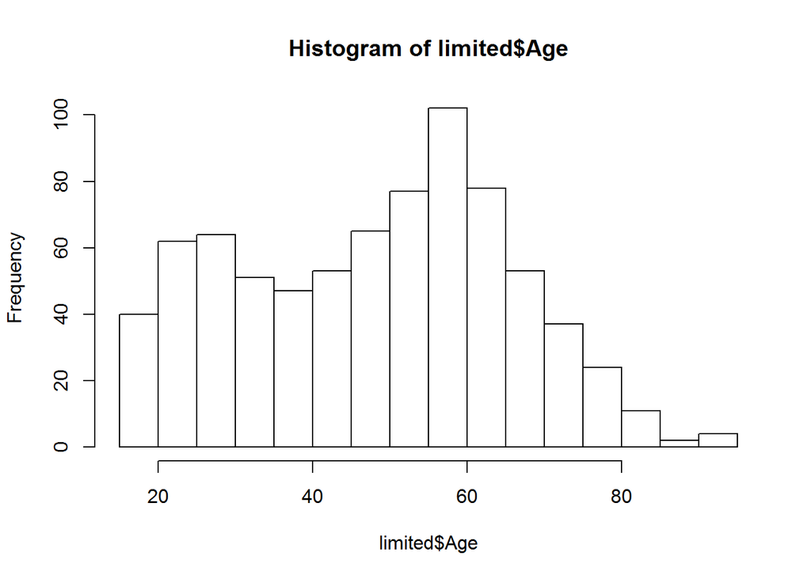

```r
#Ans:0.2558459

##############################################

#PROBLEM 4.1 - RELATING DEMOGRAPHICS TO POLLING RESULTS

#Often, we are interested in whether certain characteristics of interviewees (e.g. their age or political opinions) affect their opinions on the topic of the poll (in this case, opinions on privacy). In this section, we will investigate the relationship between the characteristics Age and Smartphone and outcome variables Info.On.Internet and Tried.Masking.Identity, again using the limited data frame we built in an earlier section of this problem.

#Build a histogram of the age of interviewees. What is the best represented age group in the population?
hist(limited$Age)
```

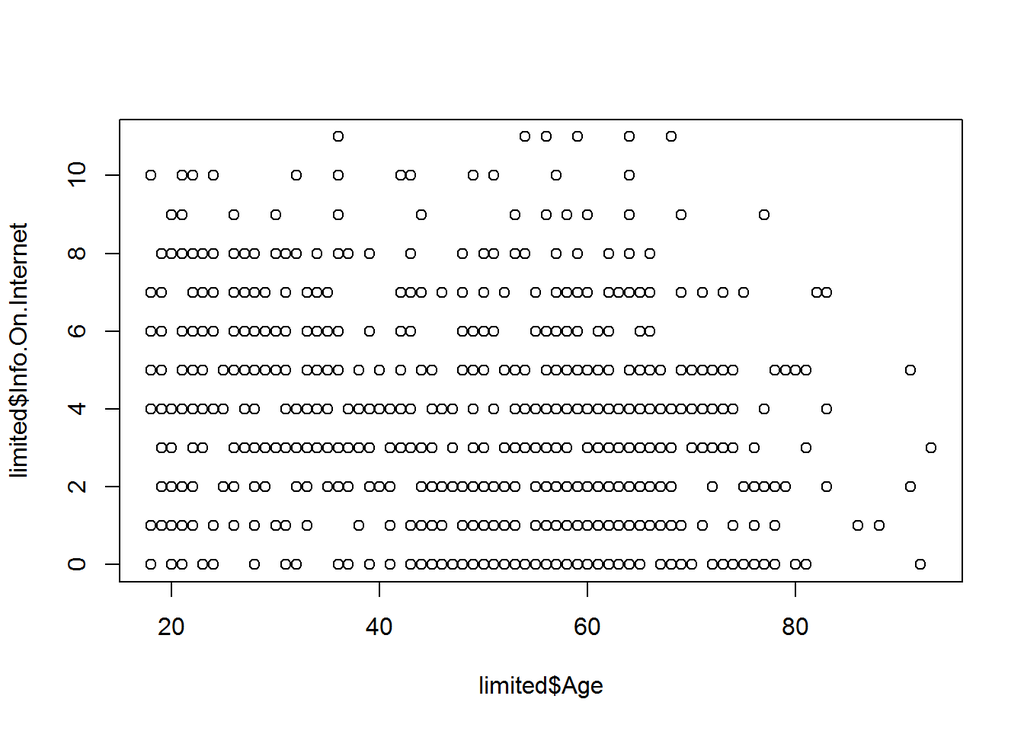

```r
#Ans:People aged about 60 years old

#Both Age and Info.On.Internet are variables that take on many values, so a good way to observe their relationship is through a graph. We learned in lecture that we can plot Age against Info.On.Internet with the command plot(limited$Age, limited$Info.On.Internet). However, because Info.On.Internet takes on a small number of values, multiple points can be plotted in exactly the same location on this graph.
plot(limited$Age, limited$Info.On.Internet)
```

```r
#What is the largest number of interviewees that have exactly the same value in their Age variable AND the same value in their Info.On.Internet variable? In other words, what is the largest number of overlapping points in the plot plot(limited$Age, limited$Info.On.Internet)? (HINT: Use the table function to compare the number of observations with different values of Age and Info.On.Internet.)
max(table(limited$Age, limited$Info.On.Internet))
```

```
## [1] 6
```

```r
#Ans:6

#To avoid points covering each other up, we can use the jitter() function on the values we pass to the plot function. Experimenting with the command jitter(c(1, 2, 3)), what appears to be the functionality of the jitter command?
jitter(c(1, 2, 3))
```

```
## [1] 1.016522 2.188608 3.189527
```

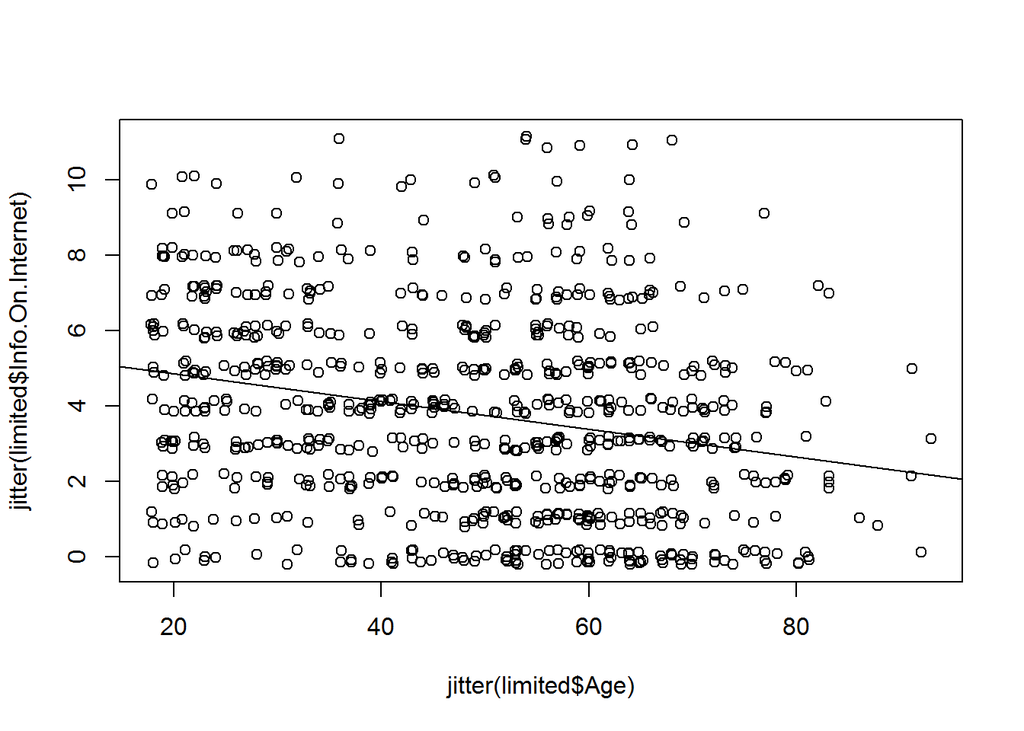

```r
#Ans:jitter adds or subtracts a small amount of random noise to the values passed to it, and two runs will yield different results
#EXPLANATION:By running the command jitter(c(1, 2, 3)) multiple times, we can see that the jitter function randomly adds or subtracts a small value from each number, and two runs will yield different results.

#Now, plot Age against Info.On.Internet with plot(jitter(limited$Age), jitter(limited$Info.On.Internet)). What relationship to you observe between Age and Info.On.Internet?
plot(jitter(limited$Age), jitter(limited$Info.On.Internet))
abline(lm(limited$Info.On.Internet~limited$Age,limited))
```

```r
#Ans:Older age seems moderately associated with a smaller value for Info.On.Internet
#EXPLANATION:For younger people aged 18-30, the average value of Info.On.Internet appears to be roughly 5, while most peopled aged 60 and older have a value less than 5. Therefore, older age appears to be associated with a smaller value of Info.On.Internet, but from the spread of dots on the image, it's clear the association is not particularly strong.

#Use the tapply() function to obtain the summary of the Info.On.Internet value, broken down by whether an interviewee is a smartphone user.
tapply(limited$Info.On.Internet,limited$Smartphone,summary)
```

```
## $`0`
##    Min. 1st Qu.  Median    Mean 3rd Qu.    Max.
##   0.000   1.000   3.000   2.923   5.000  11.000
##
## $`1`
##    Min. 1st Qu.  Median    Mean 3rd Qu.    Max.
##   0.000   2.000   4.000   4.368   6.000  11.000
```

```r
#What is the average Info.On.Internet value for smartphone users?
#Ans:4.368  #The average for smartphone users from the summary output labeled with 1.

#What is the average Info.On.Internet value for non-smartphone users?
#Ans:2.923  #We can read the average for non-smartphone users from the summary output labeled with 0

#Similarly use tapply to break down the Tried.Masking.Identity variable for smartphone and non-smartphone users.
tapply(limited$Tried.Masking.Identity,limited$Smartphone,summary)
```

```
## $`0`
##    Min. 1st Qu.  Median    Mean 3rd Qu.    Max.    NA's
##  0.0000  0.0000  0.0000  0.1174  0.0000  1.0000       4
##
## $`1`
##    Min. 1st Qu.  Median    Mean 3rd Qu.    Max.    NA's
##  0.0000  0.0000  0.0000  0.1925  0.0000  1.0000       4
```

```r
#Note when we want proportions of a variables having 0s and 1s, all we meed is the mean from the summary function.Mean gives the proportion of TRUEs.For ex:
mean(c(TRUE,TRUE,FALSE,TRUE))
```

```
## [1] 0.75
```

```r
#What proportion of smartphone users who answered the Tried.Masking.Identity question have tried masking their identity when using the Internet?
#Ans:0.1925

#What proportion of non-smartphone users who answered the Tried.Masking.Identity question have tried masking their identity when using the Internet?
#Ans:0.1174

#EXPLANATION:We can get the breakdown for smartphone and non-smartphone users with:
#tapply(limited$Tried.Masking.Identity, limited$Smartphone, table)
#Among smartphone users, 93 tried masking their identity and 390 did not, resulting in proportion 93/(93+390)=0.1925. Among non-smartphone users, 33 tried masking their identity and 248 did not, resulting in proportion 33/(33+248)=0.1174.This could have also been read from tapply(limited$Tried.Masking.Identity, limited$Smartphone, summary).
```

## Unit 2: Linear Regression

### The statistical sommelier_An introduction to linear regression

**Video1:PREDICTING THE QUALITY OF WINE**

The plots below show the relationship between two of the independent variables considered by Ashenfelter and the price of wine.

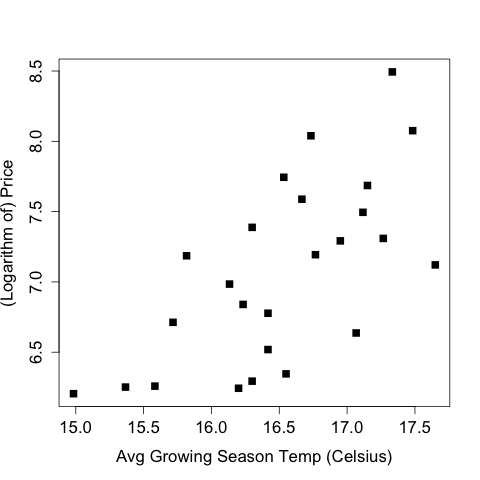

Wine_QQ1_Plot1

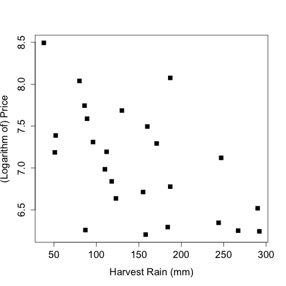

Wine_QQ1_Plot1

Q:What is the correct relationship between harvest rain, average growing season temperature, and wine prices?

Ans:More harvest rain is associated with a lower price, and higher temperatures is associated with a higher price

EXPLANATION:The plots show a positive trend between average growing season temperature and the wine price. While the trend is less clear between harvest rain and price, there is a slight negative association.

**Video2:ONE-VARIABLE LINEAR REGRESSION**

The following figure shows three data points and the best fit line

y = 3x + 2.

The x-coordinate, or “x”, is our independent variable and the y-coordinate, or “y”, is our dependent variable.

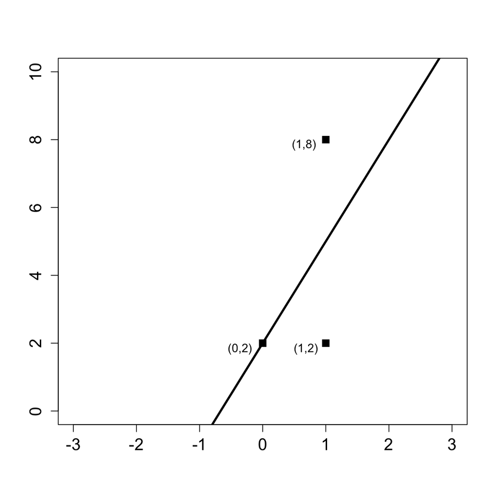

Wine_QQ2

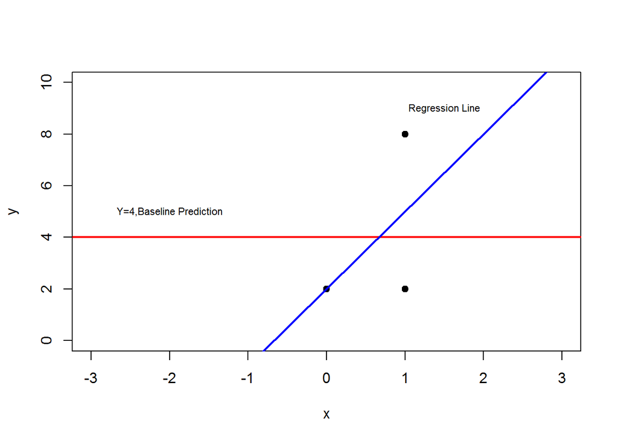

```r
#lets create the above scatter plot
x<-c(0,1,1)
y<-c(2,2,8)

plot(x,y,xlim = c(-3,3),ylim = c(0,10),pch=19)

#Baseline prediction
abline(h=mean(y),col="red",lwd=2)
text(-2,5,labels="Y=4,Baseline Prediction",cex=0.7)

#To get the SSE

#first fit the Linear model
fit1<-lm(y~x)
abline(lm(y~x),lwd=2,col="blue")
text(1.5,9,labels="Regression Line",cex = 0.7)
```

```r
anova(fit1)
```

```
## Analysis of Variance Table
##
## Response: y
##           Df Sum Sq Mean Sq F value Pr(>F)
## x          1      6       6  0.3333 0.6667
## Residuals  1     18      18
```

```r
summary(fit1)
```

```
##
## Call:
## lm(formula = y ~ x)
##
## Residuals:
##         1         2         3
## -2.22e-16 -3.00e+00  3.00e+00
##
## Coefficients:
##             Estimate Std. Error t value Pr(>|t|)
## (Intercept)    2.000      4.243   0.471    0.720
## x              3.000      5.196   0.577    0.667
##
## Residual standard error: 4.243 on 1 degrees of freedom
## Multiple R-squared:   0.25,  Adjusted R-squared:   -0.5
## F-statistic: 0.3333 on 1 and 1 DF,  p-value: 0.6667
```

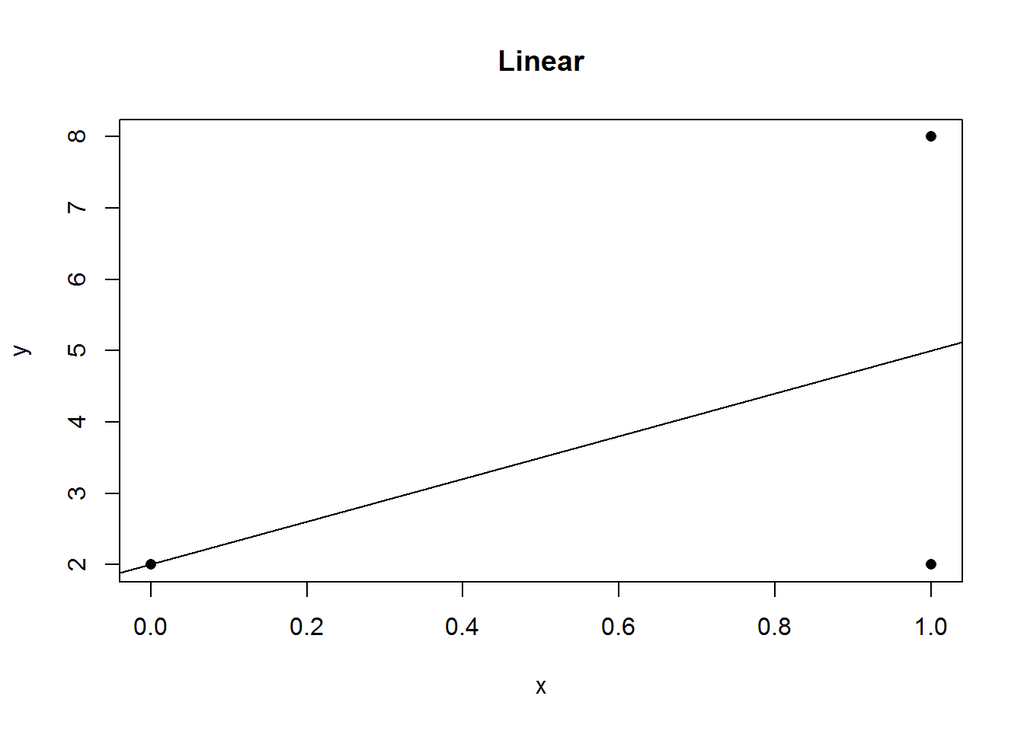

```
## Linear Fit
##  Intercept =  2
##  Slope =  3
##  R-squared =  0.25
```

```r
#Lets us SDSFoundations package which simulates all the above code to produce the scatter plot plus the basic summary o/p
library(SDSFoundations)
linFit(x,y)
```

Q:What is the baseline prediction?

Ans:4

EXPLANATION:The baseline prediction is the average value of the dependent variable. Since our dependent variable takes values 2, 2, and 8 in our data set, the average is (2+2+8)/3 = 4.

Q:What is the Sum of Squared Errors (SSE) ?

Ans:18

EXPLANATION:The SSE is computed by summing the squared errors between the actual values and our predictions. For each value of the independent variable (x), our best fit line makes the following predictions:

If x = 0, y = 3(0) + 2 = 2,

If x = 1, y = 3(1) + 2 = 5.

Thus we make an error of 0 for the data point (0,2), an error of 3 for the data point (1,2), and an error of 3 for the data point (1,8). So we have

SSE = 0² + 3² + 3² = 18.

Q:What is the Total Sum of Squares (SST) ?

Ans:24

EXPLANATION:The SST is computed by summing the squared errors between the actual values and the baseline prediction. From the first question, we computed the baseline prediction to be 4. Thus the SST is:

SST = (2 - 4)² + (2 - 4)² + (8 - 4)² = 24.

Q:What is the R² of the model?

Ans:0.25

EXPLANATION: The R² formula is:R² = 1 - SSE/SST

Thus using our answers to the previous questions, we have that

R² = 1 - 18/24 = 0.25.

**Video3:MULTIPLE LINEAR REGRESSION**

Q:Suppose we add another variable, Average Winter Temperature, to our model to predict wine price. Is it possible for the model’s R² value to go down from 0.83 to 0.80?

Ans:No, the model’s R² value can not decrease at all by adding new variables.

EXPLANATION:The model’s R² value can never decrease from adding new variables to the model. This is due to the fact that it is always possible to set the coefficient for the new variable to zero in the new model. However, this would be the same as the old model. So the only reason to make the coefficient non-zero is if it improves the R² value of the model, since linear regression picks the coefficients to minimize the error terms, which is the same as maximizing the R².

**Video4:LINEAR REGRESSION IN R**

*A script file containing all of the R commands used in this lecture reproduced below*

```r
# VIDEO 4

# Read in data
wine<-read.csv("wine.csv")
str(wine)
```

```
## 'data.frame':    25 obs. of  7 variables:
##  $ Year       : int  1952 1953 1955 1957 1958 1959 1960 1961 1962 1963 ...
##  $ Price      : num  7.5 8.04 7.69 6.98 6.78 ...
##  $ WinterRain : int  600 690 502 420 582 485 763 830 697 608 ...
##  $ AGST       : num  17.1 16.7 17.1 16.1 16.4 ...
##  $ HarvestRain: int  160 80 130 110 187 187 290 38 52 155 ...
##  $ Age        : int  31 30 28 26 25 24 23 22 21 20 ...
##  $ FrancePop  : num  43184 43495 44218 45152 45654 ...
```

```r
summary(wine)
```

```
##       Year          Price         WinterRain         AGST
##  Min.   :1952   Min.   :6.205   Min.   :376.0   Min.   :14.98
##  1st Qu.:1960   1st Qu.:6.519   1st Qu.:536.0   1st Qu.:16.20
##  Median :1966   Median :7.121   Median :600.0   Median :16.53
##  Mean   :1966   Mean   :7.067   Mean   :605.3   Mean   :16.51
##  3rd Qu.:1972   3rd Qu.:7.495   3rd Qu.:697.0   3rd Qu.:17.07
##  Max.   :1978   Max.   :8.494   Max.   :830.0   Max.   :17.65
##   HarvestRain         Age         FrancePop
##  Min.   : 38.0   Min.   : 5.0   Min.   :43184
##  1st Qu.: 89.0   1st Qu.:11.0   1st Qu.:46584
##  Median :130.0   Median :17.0   Median :50255
##  Mean   :148.6   Mean   :17.2   Mean   :49694
##  3rd Qu.:187.0   3rd Qu.:23.0   3rd Qu.:52894
##  Max.   :292.0   Max.   :31.0   Max.   :54602
```

```r
# Linear Regression (one variable)
model1<-lm(Price ~ AGST, data=wine)
summary(model1)
```

```
##
## Call:
## lm(formula = Price ~ AGST, data = wine)
##
## Residuals:
##      Min       1Q   Median       3Q      Max
## -0.78450 -0.23882 -0.03727  0.38992  0.90318
##
## Coefficients:
##             Estimate Std. Error t value Pr(>|t|)
## (Intercept)  -3.4178     2.4935  -1.371 0.183710
## AGST          0.6351     0.1509   4.208 0.000335 ***
## ---
## Signif. codes:  0 '***' 0.001 '**' 0.01 '*' 0.05 '.' 0.1 ' ' 1
##
## Residual standard error: 0.4993 on 23 degrees of freedom
## Multiple R-squared:  0.435,  Adjusted R-squared:  0.4105
## F-statistic: 17.71 on 1 and 23 DF,  p-value: 0.000335
```

```r
# Sum of Squared Errors
model1$residuals
```

```
##           1           2           3           4           5           6
##  0.04204258  0.82983774  0.21169394  0.15609432 -0.23119140  0.38991701
##           7           8           9          10          11          12
## -0.48959140  0.90318115  0.45372410  0.14887461 -0.23882157 -0.08974238
##          13          14          15          16          17          18
##  0.66185660 -0.05211511 -0.62726647 -0.74714947  0.42113502 -0.03727441
##          19          20          21          22          23          24
##  0.10685278 -0.78450270 -0.64017590 -0.05508720 -0.67055321 -0.22040381
##          25
##  0.55866518
```

```r
SSE<-sum(model1$residuals^2)
SSE
```

```
## [1] 5.734875
```

```r
# Linear Regression (two variables)
model2<-lm(Price ~ AGST + HarvestRain, data=wine)
summary(model2)
```

```
##
## Call:
## lm(formula = Price ~ AGST + HarvestRain, data = wine)
##
## Residuals:
##      Min       1Q   Median       3Q      Max
## -0.88321 -0.19600  0.06178  0.15379  0.59722
##
## Coefficients:
##             Estimate Std. Error t value Pr(>|t|)
## (Intercept) -2.20265    1.85443  -1.188 0.247585
## AGST         0.60262    0.11128   5.415 1.94e-05 ***
## HarvestRain -0.00457    0.00101  -4.525 0.000167 ***
## ---
## Signif. codes:  0 '***' 0.001 '**' 0.01 '*' 0.05 '.' 0.1 ' ' 1
##
## Residual standard error: 0.3674 on 22 degrees of freedom
## Multiple R-squared:  0.7074, Adjusted R-squared:  0.6808
## F-statistic: 26.59 on 2 and 22 DF,  p-value: 1.347e-06
```

```r
# Sum of Squared Errors
SSE<-sum(model2$residuals^2)
SSE
```

```
## [1] 2.970373
```

```r
# Linear Regression (all variables)
model3<-lm(Price ~ AGST + HarvestRain + WinterRain + Age + FrancePop, data=wine)
summary(model3)
```

```
##
## Call:
## lm(formula = Price ~ AGST + HarvestRain + WinterRain + Age +
##     FrancePop, data = wine)
##
## Residuals:
##      Min       1Q   Median       3Q      Max
## -0.48179 -0.24662 -0.00726  0.22012  0.51987
##
## Coefficients:
##               Estimate Std. Error t value Pr(>|t|)
## (Intercept) -4.504e-01  1.019e+01  -0.044 0.965202
## AGST         6.012e-01  1.030e-01   5.836 1.27e-05 ***
## HarvestRain -3.958e-03  8.751e-04  -4.523 0.000233 ***
## WinterRain   1.043e-03  5.310e-04   1.963 0.064416 .
## Age          5.847e-04  7.900e-02   0.007 0.994172
## FrancePop   -4.953e-05  1.667e-04  -0.297 0.769578
## ---
## Signif. codes:  0 '***' 0.001 '**' 0.01 '*' 0.05 '.' 0.1 ' ' 1
##
## Residual standard error: 0.3019 on 19 degrees of freedom
## Multiple R-squared:  0.8294, Adjusted R-squared:  0.7845
## F-statistic: 18.47 on 5 and 19 DF,  p-value: 1.044e-06
```

```r
# Sum of Squared Errors
SSE<-sum(model3$residuals^2)
SSE
```

```
## [1] 1.732113
```

```r
####################################################

#In R, use the dataset wine.csv to create a linear regression model to predict Price using HarvestRain and WinterRain as independent variables. Using the summary output of this model, answer the following questions:
fit2<-lm(Price ~ HarvestRain + WinterRain, data=wine)
summary(fit2)
```

```
##
## Call:
## lm(formula = Price ~ HarvestRain + WinterRain, data = wine)
##
## Residuals:
##     Min      1Q  Median      3Q     Max
## -1.0933 -0.3222 -0.1012  0.3871  1.1877
##
## Coefficients:
##               Estimate Std. Error t value Pr(>|t|)
## (Intercept)  7.865e+00  6.616e-01  11.888 4.76e-11 ***
## HarvestRain -4.971e-03  1.601e-03  -3.105  0.00516 **
## WinterRain  -9.848e-05  9.007e-04  -0.109  0.91392
## ---
## Signif. codes:  0 '***' 0.001 '**' 0.01 '*' 0.05 '.' 0.1 ' ' 1
##
## Residual standard error: 0.5611 on 22 degrees of freedom
## Multiple R-squared:  0.3177, Adjusted R-squared:  0.2557
## F-statistic: 5.122 on 2 and 22 DF,  p-value: 0.01492
```

```r
#What is the "Multiple R-squared" value of your model?
#Ans: 0.3177

#What is the coefficient for HarvestRain?
#Ans:-4.971e-03   i.e.???4.971×10???03

#What is the intercept coefficient?
#Ans:7.865
#EXPLANATION:In R, create the model by typing the following line into your R console:
#modelQQ4 = lm(Price ~ HarvestRain + WinterRain, data=wine)
#Then, look at the output of summary(modelQQ4). The Multiple R-squared is listed at the bottom of the output, and the coefficients can be found in the coefficients table.
```

**Video5:UNDERSTANDING THE MODEL**

*A script file containing all of the R commands used in this lecture reproduced below*

```r
# VIDEO 5
wine<-read.csv("wine.csv")

model3<-lm(Price ~ AGST + HarvestRain + WinterRain + Age + FrancePop, data<-wine)
summary(model3)
```

```
##
## Call:
## lm(formula = Price ~ AGST + HarvestRain + WinterRain + Age +
##     FrancePop, data = data <- wine)
##
## Residuals:
##      Min       1Q   Median       3Q      Max
## -0.48179 -0.24662 -0.00726  0.22012  0.51987
##
## Coefficients:
##               Estimate Std. Error t value Pr(>|t|)
## (Intercept) -4.504e-01  1.019e+01  -0.044 0.965202
## AGST         6.012e-01  1.030e-01   5.836 1.27e-05 ***
## HarvestRain -3.958e-03  8.751e-04  -4.523 0.000233 ***
## WinterRain   1.043e-03  5.310e-04   1.963 0.064416 .
## Age          5.847e-04  7.900e-02   0.007 0.994172
## FrancePop   -4.953e-05  1.667e-04  -0.297 0.769578
## ---
## Signif. codes:  0 '***' 0.001 '**' 0.01 '*' 0.05 '.' 0.1 ' ' 1
##
## Residual standard error: 0.3019 on 19 degrees of freedom
## Multiple R-squared:  0.8294, Adjusted R-squared:  0.7845
## F-statistic: 18.47 on 5 and 19 DF,  p-value: 1.044e-06
```

```r
# Remove FrancePop
model4<-lm(Price ~ AGST + HarvestRain + WinterRain + Age, data=wine)
summary(model4)
```

```
##
## Call:
## lm(formula = Price ~ AGST + HarvestRain + WinterRain + Age, data = wine)
##
## Residuals:
##      Min       1Q   Median       3Q      Max
## -0.45470 -0.24273  0.00752  0.19773  0.53637
##
## Coefficients:
##               Estimate Std. Error t value Pr(>|t|)
## (Intercept) -3.4299802  1.7658975  -1.942 0.066311 .
## AGST         0.6072093  0.0987022   6.152  5.2e-06 ***
## HarvestRain -0.0039715  0.0008538  -4.652 0.000154 ***
## WinterRain   0.0010755  0.0005073   2.120 0.046694 *
## Age          0.0239308  0.0080969   2.956 0.007819 **
## ---
## Signif. codes:  0 '***' 0.001 '**' 0.01 '*' 0.05 '.' 0.1 ' ' 1
##
## Residual standard error: 0.295 on 20 degrees of freedom
## Multiple R-squared:  0.8286, Adjusted R-squared:  0.7943
## F-statistic: 24.17 on 4 and 20 DF,  p-value: 2.036e-07
```

```r
#########################################

#Use the dataset wine.csv to create a linear regression model to predict Price using HarvestRain and WinterRain as independent variables, like you did in the previous quick question. Using the summary output of this model, answer the following questions:
fit2<-lm(Price ~ HarvestRain + WinterRain, data<-wine)
summary(fit2)
```

```
##
## Call:
## lm(formula = Price ~ HarvestRain + WinterRain, data = data <- wine)
##
## Residuals:
##     Min      1Q  Median      3Q     Max
## -1.0933 -0.3222 -0.1012  0.3871  1.1877
##
## Coefficients:
##               Estimate Std. Error t value Pr(>|t|)
## (Intercept)  7.865e+00  6.616e-01  11.888 4.76e-11 ***
## HarvestRain -4.971e-03  1.601e-03  -3.105  0.00516 **
## WinterRain  -9.848e-05  9.007e-04  -0.109  0.91392
## ---
## Signif. codes:  0 '***' 0.001 '**' 0.01 '*' 0.05 '.' 0.1 ' ' 1
##
## Residual standard error: 0.5611 on 22 degrees of freedom
## Multiple R-squared:  0.3177, Adjusted R-squared:  0.2557
## F-statistic: 5.122 on 2 and 22 DF,  p-value: 0.01492
```

```r
#Is the coefficient for HarvestRain significant?
#Ans:Yes

#Is the coefficient for WinterRain significant?
#Ans:No
```

**Video6:CORRELATION AND MULTICOLLINEARITY**

*A script file containing all of the R commands used in this lecture reproduced below*

```r
# VIDEO 6

wine<-read.csv("wine.csv")

# Correlations
cor(wine$WinterRain, wine$Price)
```

```
## [1] 0.1366505
```

```r
cor(wine$Age, wine$FrancePop)
```

```
## [1] -0.9944851
```

```r
cor(wine) #correlation matrix
```

```
##                    Year      Price   WinterRain        AGST HarvestRain
## Year         1.00000000 -0.4477679  0.016970024 -0.24691585  0.02800907
## Price       -0.44776786  1.0000000  0.136650547  0.65956286 -0.56332190
## WinterRain   0.01697002  0.1366505  1.000000000 -0.32109061 -0.27544085
## AGST        -0.24691585  0.6595629 -0.321090611  1.00000000 -0.06449593
## HarvestRain  0.02800907 -0.5633219 -0.275440854 -0.06449593  1.00000000
## Age         -1.00000000  0.4477679 -0.016970024  0.24691585 -0.02800907
## FrancePop    0.99448510 -0.4668616 -0.001621627 -0.25916227  0.04126439
##                     Age    FrancePop
## Year        -1.00000000  0.994485097
## Price        0.44776786 -0.466861641
## WinterRain  -0.01697002 -0.001621627
## AGST         0.24691585 -0.259162274
## HarvestRain -0.02800907  0.041264394
## Age          1.00000000 -0.994485097
## FrancePop   -0.99448510  1.000000000
```

```r
# Remove Age and FrancePop as they were highly  correlated
model5<-lm(Price ~ AGST + HarvestRain + WinterRain, data=wine)
summary(model5)
```

```
##
## Call:
## lm(formula = Price ~ AGST + HarvestRain + WinterRain, data = wine)
##
## Residuals:
##      Min       1Q   Median       3Q      Max
## -0.67472 -0.12958  0.01973  0.20751  0.63846
##
## Coefficients:
##               Estimate Std. Error t value Pr(>|t|)
## (Intercept) -4.3016263  2.0366743  -2.112 0.046831 *
## AGST         0.6810242  0.1117011   6.097 4.75e-06 ***
## HarvestRain -0.0039481  0.0009987  -3.953 0.000726 ***
## WinterRain   0.0011765  0.0005920   1.987 0.060097 .
## ---
## Signif. codes:  0 '***' 0.001 '**' 0.01 '*' 0.05 '.' 0.1 ' ' 1
##
## Residual standard error: 0.345 on 21 degrees of freedom
## Multiple R-squared:  0.7537, Adjusted R-squared:  0.7185
## F-statistic: 21.42 on 3 and 21 DF,  p-value: 1.359e-06
```

```r
#removing both correlated IVs Age & FrancePop results in lowering of Rsqrd & Adjusted R-squared.Hence finalyly we should remove FrancePop as intuitively Age of Wine is a better/imp predictor of Price of Wine

##########################################

#Using the data set wine.csv, what is the correlation between HarvestRain and WinterRain?
cor(wine$HarvestRain,wine$WinterRain)
```

```
## [1] -0.2754409
```

```r
#Ans:-0.2754409
```

**Video7:MAKING PREDICTIONS**

*A script file containing all of the R commands used in this lecture reproduced below*

```r
# VIDEO 7

# Read in test set
wineTest<-read.csv("wine_test.csv")
str(wineTest)
```

```
## 'data.frame':    2 obs. of  7 variables:
##  $ Year       : int  1979 1980
##  $ Price      : num  6.95 6.5
##  $ WinterRain : int  717 578
##  $ AGST       : num  16.2 16
##  $ HarvestRain: int  122 74
##  $ Age        : int  4 3
##  $ FrancePop  : num  54836 55110
```

```r
# Make test set predictions using predict()
predictTest<-predict(model4, newdata=wineTest)
predictTest
```

```
##        1        2
## 6.768925 6.684910
```

```r
# Compute R-squared
SSE<-sum((wineTest$Price - predictTest)^2)
SST<-sum((wineTest$Price - mean(wine$Price))^2)
1 - SSE/SST
```

```
## [1] 0.7944278
```

Q:Which of the following are NOT valid values for an out-of-sample (test set) R² ? Select all that apply.

Ans:2.4

EXPLANATION:The formula for R² is

R² = 1 - SSE/SST,where SST is calculated using the average value of the dependent variable on the training set.Since SSE and SST are the sums of squared terms, we know that both will be positive. Thus SSE/SST must be greater than or equal to zero. This means it is not possible to have an out-of-sample R² value of 2.4.However, all other values are valid (even the negative ones!), since SSE can be more or less than SST, due to the fact that this is an out-of-sample R², not a model R².

### Moneyball_The power of sports analytics

**VIDEO 2: MAKING IT TO THE PLAYOFFS**

*A script file containing all of the R commands used in this lecture reproduced below*

```r
# VIDEO 2

# Read in data
baseball<-read.csv("baseball.csv")
str(baseball)
```

```
## 'data.frame':    1232 obs. of  15 variables:
##  $ Team        : Factor w/ 39 levels "ANA","ARI","ATL",..: 2 3 4 5 7 8 9 10 11 12 ...
##  $ League      : Factor w/ 2 levels "AL","NL": 2 2 1 1 2 1 2 1 2 1 ...
##  $ Year        : int  2012 2012 2012 2012 2012 2012 2012 2012 2012 2012 ...
##  $ RS          : int  734 700 712 734 613 748 669 667 758 726 ...
##  $ RA          : int  688 600 705 806 759 676 588 845 890 670 ...
##  $ W           : int  81 94 93 69 61 85 97 68 64 88 ...
##  $ OBP         : num  0.328 0.32 0.311 0.315 0.302 0.318 0.315 0.324 0.33 0.335 ...
##  $ SLG         : num  0.418 0.389 0.417 0.415 0.378 0.422 0.411 0.381 0.436 0.422 ...
##  $ BA          : num  0.259 0.247 0.247 0.26 0.24 0.255 0.251 0.251 0.274 0.268 ...
##  $ Playoffs    : int  0 1 1 0 0 0 1 0 0 1 ...
##  $ RankSeason  : int  NA 4 5 NA NA NA 2 NA NA 6 ...
##  $ RankPlayoffs: int  NA 5 4 NA NA NA 4 NA NA 2 ...
##  $ G           : int  162 162 162 162 162 162 162 162 162 162 ...
##  $ OOBP        : num  0.317 0.306 0.315 0.331 0.335 0.319 0.305 0.336 0.357 0.314 ...
##  $ OSLG        : num  0.415 0.378 0.403 0.428 0.424 0.405 0.39 0.43 0.47 0.402 ...
```

```r
# Subset to only include moneyball years before 2002
moneyball<-subset(baseball, Year < 2002)
str(moneyball)
```

```
## 'data.frame':    902 obs. of  15 variables:
##  $ Team        : Factor w/ 39 levels "ANA","ARI","ATL",..: 1 2 3 4 5 7 8 9 10 11 ...
##  $ League      : Factor w/ 2 levels "AL","NL": 1 2 2 1 1 2 1 2 1 2 ...
##  $ Year        : int  2001 2001 2001 2001 2001 2001 2001 2001 2001 2001 ...
##  $ RS          : int  691 818 729 687 772 777 798 735 897 923 ...
##  $ RA          : int  730 677 643 829 745 701 795 850 821 906 ...
##  $ W           : int  75 92 88 63 82 88 83 66 91 73 ...
##  $ OBP         : num  0.327 0.341 0.324 0.319 0.334 0.336 0.334 0.324 0.35 0.354 ...
##  $ SLG         : num  0.405 0.442 0.412 0.38 0.439 0.43 0.451 0.419 0.458 0.483 ...
##  $ BA          : num  0.261 0.267 0.26 0.248 0.266 0.261 0.268 0.262 0.278 0.292 ...
##  $ Playoffs    : int  0 1 1 0 0 0 0 0 1 0 ...
##  $ RankSeason  : int  NA 5 7 NA NA NA NA NA 6 NA ...
##  $ RankPlayoffs: int  NA 1 3 NA NA NA NA NA 4 NA ...
##  $ G           : int  162 162 162 162 161 162 162 162 162 162 ...
##  $ OOBP        : num  0.331 0.311 0.314 0.337 0.329 0.321 0.334 0.341 0.341 0.35 ...
##  $ OSLG        : num  0.412 0.404 0.384 0.439 0.393 0.398 0.427 0.455 0.417 0.48 ...
```

```r
# Compute Run Difference and add this new var to the dataframe
moneyball$RD<-moneyball$RS - moneyball$RA
str(moneyball)
```

```
## 'data.frame':    902 obs. of  16 variables:
##  $ Team        : Factor w/ 39 levels "ANA","ARI","ATL",..: 1 2 3 4 5 7 8 9 10 11 ...
##  $ League      : Factor w/ 2 levels "AL","NL": 1 2 2 1 1 2 1 2 1 2 ...
##  $ Year        : int  2001 2001 2001 2001 2001 2001 2001 2001 2001 2001 ...
##  $ RS          : int  691 818 729 687 772 777 798 735 897 923 ...
##  $ RA          : int  730 677 643 829 745 701 795 850 821 906 ...
##  $ W           : int  75 92 88 63 82 88 83 66 91 73 ...
##  $ OBP         : num  0.327 0.341 0.324 0.319 0.334 0.336 0.334 0.324 0.35 0.354 ...
##  $ SLG         : num  0.405 0.442 0.412 0.38 0.439 0.43 0.451 0.419 0.458 0.483 ...
##  $ BA          : num  0.261 0.267 0.26 0.248 0.266 0.261 0.268 0.262 0.278 0.292 ...
##  $ Playoffs    : int  0 1 1 0 0 0 0 0 1 0 ...
##  $ RankSeason  : int  NA 5 7 NA NA NA NA NA 6 NA ...
##  $ RankPlayoffs: int  NA 1 3 NA NA NA NA NA 4 NA ...
##  $ G           : int  162 162 162 162 161 162 162 162 162 162 ...
##  $ OOBP        : num  0.331 0.311 0.314 0.337 0.329 0.321 0.334 0.341 0.341 0.35 ...
##  $ OSLG        : num  0.412 0.404 0.384 0.439 0.393 0.398 0.427 0.455 0.417 0.48 ...
##  $ RD          : int  -39 141 86 -142 27 76 3 -115 76 17 ...
```

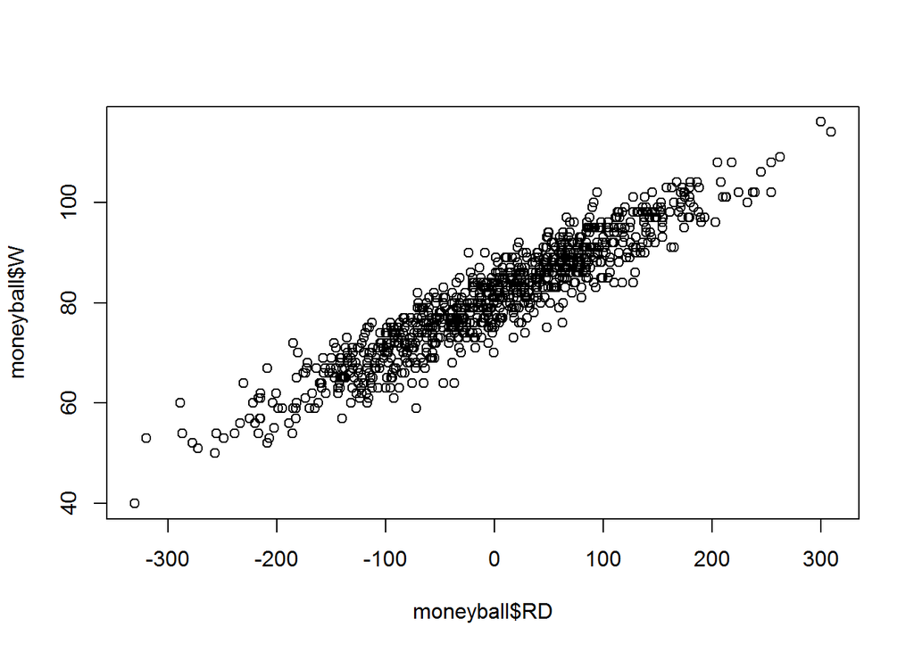

```r
# Scatterplot to check for linear relationship
plot(moneyball$RD, moneyball$W)
```

```r
# Regression model to predict wins
WinsReg<-lm(W ~ RD, data=moneyball)
summary(WinsReg)
```

```
##
## Call:
## lm(formula = W ~ RD, data = moneyball)
##
## Residuals:
##      Min       1Q   Median       3Q      Max
## -14.2662  -2.6509   0.1234   2.9364  11.6570
##
## Coefficients:
##              Estimate Std. Error t value Pr(>|t|)
## (Intercept) 80.881375   0.131157  616.67   <2e-16 ***
## RD           0.105766   0.001297   81.55   <2e-16 ***
## ---
## Signif. codes:  0 '***' 0.001 '**' 0.01 '*' 0.05 '.' 0.1 ' ' 1
##
## Residual standard error: 3.939 on 900 degrees of freedom
## Multiple R-squared:  0.8808, Adjusted R-squared:  0.8807
## F-statistic:  6651 on 1 and 900 DF,  p-value: < 2.2e-16
```

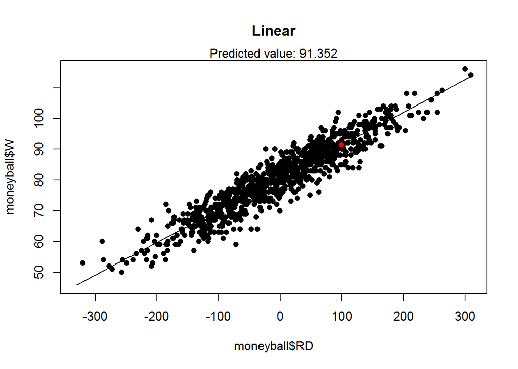

```r
##########################################

#If a baseball team scores 713 runs and allows 614 runs, how many games do we expect the team to win?

#Using the linear regression model constructed during the lecture, enter the number of games we expect the team to win:

library(SDSFoundations)
rdiff<-713-614
linFitPred(moneyball$RD,moneyball$W,rdiff)
```

```r
#Ans:91.352
#EXPLANATION:Our linear regression model was
#Wins = 80.88 + 0.1058*(Run Difference)
#Here, the run difference is 99, so our prediction is
#Wins = 80.88 + 0.1058*99 = 91 games.
```

**VIDEO 3: PREDICTING RUNS**

*A script file containing all of the R commands used in this lecture reproduced below*

```r
# VIDEO 3

# Read in data
baseball<-read.csv("baseball.csv")

# Subset to only include moneyball years before 2002
moneyball<-subset(baseball, Year < 2002)
str(moneyball)
```

```
## 'data.frame':    902 obs. of  15 variables:
##  $ Team        : Factor w/ 39 levels "ANA","ARI","ATL",..: 1 2 3 4 5 7 8 9 10 11 ...
##  $ League      : Factor w/ 2 levels "AL","NL": 1 2 2 1 1 2 1 2 1 2 ...
##  $ Year        : int  2001 2001 2001 2001 2001 2001 2001 2001 2001 2001 ...
##  $ RS          : int  691 818 729 687 772 777 798 735 897 923 ...
##  $ RA          : int  730 677 643 829 745 701 795 850 821 906 ...
##  $ W           : int  75 92 88 63 82 88 83 66 91 73 ...
##  $ OBP         : num  0.327 0.341 0.324 0.319 0.334 0.336 0.334 0.324 0.35 0.354 ...
##  $ SLG         : num  0.405 0.442 0.412 0.38 0.439 0.43 0.451 0.419 0.458 0.483 ...
##  $ BA          : num  0.261 0.267 0.26 0.248 0.266 0.261 0.268 0.262 0.278 0.292 ...
##  $ Playoffs    : int  0 1 1 0 0 0 0 0 1 0 ...
##  $ RankSeason  : int  NA 5 7 NA NA NA NA NA 6 NA ...
##  $ RankPlayoffs: int  NA 1 3 NA NA NA NA NA 4 NA ...
##  $ G           : int  162 162 162 162 161 162 162 162 162 162 ...
##  $ OOBP        : num  0.331 0.311 0.314 0.337 0.329 0.321 0.334 0.341 0.341 0.35 ...
##  $ OSLG        : num  0.412 0.404 0.384 0.439 0.393 0.398 0.427 0.455 0.417 0.48 ...
```

```r
# Compute Run Difference and add this new var to the dataframe
moneyball$RD<-moneyball$RS - moneyball$RA
str(moneyball)
```

```
## 'data.frame':    902 obs. of  16 variables:
##  $ Team        : Factor w/ 39 levels "ANA","ARI","ATL",..: 1 2 3 4 5 7 8 9 10 11 ...
##  $ League      : Factor w/ 2 levels "AL","NL": 1 2 2 1 1 2 1 2 1 2 ...
##  $ Year        : int  2001 2001 2001 2001 2001 2001 2001 2001 2001 2001 ...
##  $ RS          : int  691 818 729 687 772 777 798 735 897 923 ...
##  $ RA          : int  730 677 643 829 745 701 795 850 821 906 ...
##  $ W           : int  75 92 88 63 82 88 83 66 91 73 ...
##  $ OBP         : num  0.327 0.341 0.324 0.319 0.334 0.336 0.334 0.324 0.35 0.354 ...
##  $ SLG         : num  0.405 0.442 0.412 0.38 0.439 0.43 0.451 0.419 0.458 0.483 ...
##  $ BA          : num  0.261 0.267 0.26 0.248 0.266 0.261 0.268 0.262 0.278 0.292 ...
##  $ Playoffs    : int  0 1 1 0 0 0 0 0 1 0 ...
##  $ RankSeason  : int  NA 5 7 NA NA NA NA NA 6 NA ...
##  $ RankPlayoffs: int  NA 1 3 NA NA NA NA NA 4 NA ...
##  $ G           : int  162 162 162 162 161 162 162 162 162 162 ...
##  $ OOBP        : num  0.331 0.311 0.314 0.337 0.329 0.321 0.334 0.341 0.341 0.35 ...
##  $ OSLG        : num  0.412 0.404 0.384 0.439 0.393 0.398 0.427 0.455 0.417 0.48 ...
##  $ RD          : int  -39 141 86 -142 27 76 3 -115 76 17 ...
```

```r
# Regression model to predict runs scored
RunsReg<-lm(RS ~ OBP + SLG + BA, data=moneyball)
summary(RunsReg) #BA coeff is negative impying that a team will score more runs if BA is lower which is counterintuitive....this must be due to existence of multicollinearity....now lets remove BA from the model
```

```
##
## Call:
## lm(formula = RS ~ OBP + SLG + BA, data = moneyball)
##
## Residuals:
##     Min      1Q  Median      3Q     Max
## -70.941 -17.247  -0.621  16.754  90.998
##
## Coefficients:
##             Estimate Std. Error t value Pr(>|t|)
## (Intercept)  -788.46      19.70 -40.029  < 2e-16 ***
## OBP          2917.42     110.47  26.410  < 2e-16 ***
## SLG          1637.93      45.99  35.612  < 2e-16 ***
## BA           -368.97     130.58  -2.826  0.00482 **
## ---
## Signif. codes:  0 '***' 0.001 '**' 0.01 '*' 0.05 '.' 0.1 ' ' 1
##
## Residual standard error: 24.69 on 898 degrees of freedom
## Multiple R-squared:  0.9302, Adjusted R-squared:   0.93
## F-statistic:  3989 on 3 and 898 DF,  p-value: < 2.2e-16
```

```r
RunsReg<-lm(RS ~ OBP + SLG, data=moneyball)
summary(RunsReg)
```

```
##
## Call:
## lm(formula = RS ~ OBP + SLG, data = moneyball)
##
## Residuals:
##     Min      1Q  Median      3Q     Max
## -70.838 -17.174  -1.108  16.770  90.036
##
## Coefficients:
##             Estimate Std. Error t value Pr(>|t|)
## (Intercept)  -804.63      18.92  -42.53   <2e-16 ***
## OBP          2737.77      90.68   30.19   <2e-16 ***
## SLG          1584.91      42.16   37.60   <2e-16 ***
## ---
## Signif. codes:  0 '***' 0.001 '**' 0.01 '*' 0.05 '.' 0.1 ' ' 1
##
## Residual standard error: 24.79 on 899 degrees of freedom
## Multiple R-squared:  0.9296, Adjusted R-squared:  0.9294
## F-statistic:  5934 on 2 and 899 DF,  p-value: < 2.2e-16
```

```r
#this is a simple (parsimonious) model giving significant coeff with high Rsqred.Also seeing the coeff of OBP & SLG which are of same scale,OBP has a higher coeff impying that OBP is probably worth more than SLG.

#########################################

#If a baseball team's OBP is 0.311 and SLG is 0.405, how many runs do we expect the team to score?

#Using the linear regression model constructed during the lecture (the one that uses OBP and SLG as independent variables), enter the number of runs we expect the team to score:
summary(RunsReg)
```

```
##
## Call:
## lm(formula = RS ~ OBP + SLG, data = moneyball)
##
## Residuals:
##     Min      1Q  Median      3Q     Max
## -70.838 -17.174  -1.108  16.770  90.036
##
## Coefficients:
##             Estimate Std. Error t value Pr(>|t|)
## (Intercept)  -804.63      18.92  -42.53   <2e-16 ***
## OBP          2737.77      90.68   30.19   <2e-16 ***
## SLG          1584.91      42.16   37.60   <2e-16 ***
## ---
## Signif. codes:  0 '***' 0.001 '**' 0.01 '*' 0.05 '.' 0.1 ' ' 1
##
## Residual standard error: 24.79 on 899 degrees of freedom
## Multiple R-squared:  0.9296, Adjusted R-squared:  0.9294
## F-statistic:  5934 on 2 and 899 DF,  p-value: < 2.2e-16
```

```r
-804.63+(0.311* 2737.77)+(0.405*1584.91)#from summary o/p
```

```
## [1] 688.705
```

```r
#Ans:689
#EXPLANATION:Our linear regression model was:
#Runs Scored = -804.63 + 2737.77*(OBP) + 1584.91*(SLG)
#Here, OBP is 0.311 and SLG is 0.405, so our prediction is:
#Runs Scored = -804.63 + 2737.77*0.311 + 1584.91*0.405 = 689 runs


#If a baseball team's opponents OBP (OOBP) is 0.297 and oppenents SLG (OSLG) is 0.370, how many runs do we expect the team to allow?

#Using the linear regression model discussed during the lecture (the one on the last slide of the previous video), enter the number of runs we expect the team to allow:
-837.38+( 0.297*2913.60)+(0.370*1514.29)
```

```
## [1] 588.2465
```

```r
#Ans:588
#EXPLANATION:Our linear regression model was:
#Runs Allowed = -837.38 + 2913.60*(OOBP) + 1514.29*(OSLG)
#Here, OOBP is 0.297 and OSLG is 0.370, so our prediction is:
#Runs Scored = -837.38 + 2913.60*(.297) + 1514.29*(.370) = 588 runs
```

**VIDEO 4: USING THE MODELS TO MAKE PREDICTIONS**

Q:Suppose you are the General Manager of a baseball team, and you are selecting TWO players for your team. You have a budget of $1,500,000, and you have the choice between the following players:

Player Name OBP SLG Salary Eric Chavez 0.338 0.540 $1,400,000 Jeremy Giambi 0.391 0.450 $1,065,000 Frank Menechino 0.369 0.374 $295,000 Greg Myers 0.313 0.447 $800,000 Carlos Pena 0.361 0.500 $300,000 Given your budget and the player statistics, which TWO players would you select?

Ans:Jeremy Giambi & Carlos Pena

EXPLANATION:We would select Jeremy Giambi and Carlos Pena, since they give the highest contribution to Runs Scored.We would not select Eric Chavez, since his salary consumes our entire budget, and although he has the highest SLG, there are players with better OBP.We would not select Frank Menechino since even though he has a high OBP, his SLG is low.We would not select Greg Myers since he is dominated by Carlos Pena in OBP and SLG, but has a much higher salary.

**VIDEO 5: WINNING THE WORLD SERIES**

In 2012 and 2013, there were 10 teams in the MLB playoffs: the six teams that had the most wins in each baseball division, and four “wild card” teams. The playoffs start between the four wild card teams - the two teams that win proceed in the playoffs (8 teams remaining). Then, these teams are paired off and play a series of games. The four teams that win are then paired and play to determine who will play in the World Series.

We can assign rankings to the teams as follows:

Rank 1: the team that won the World Series Rank 2: the team that lost the World Series Rank 3: the two teams that lost to the teams in the World Series Rank 4: the four teams that made it past the wild card round, but lost to the above four teams Rank 5: the two teams that lost the wild card round In your R console, create a corresponding rank vector by typing teamRank<-c(1,2,3,3,4,4,4,4,5,5)

In this quick question, we’ll see how well these rankings correlate with the regular season wins of the teams. In 2012, the ranking of the teams and their regular season wins were as follows:

Rank 1: San Francisco Giants (Wins = 94) Rank 2: Detroit Tigers (Wins = 88) Rank 3: New York Yankees (Wins = 95), and St. Louis Cardinals (Wins = 88) Rank 4: Baltimore Orioles (Wins = 93), Oakland A’s (Wins = 94), Washington Nationals (Wins = 98), Cincinnati Reds (Wins = 97) Rank 5: Texas Rangers (Wins = 93), and Atlanta Braves (Wins = 94) Create a vector in R called wins2012, that has the wins of each team in 2012, in order of rank (the vector should have 10 numbers).

In 2013, the ranking of the teams and their regular season wins were as follows:

Rank 1: Boston Red Sox (Wins = 97) Rank 2: St. Louis Cardinals (Wins = 97) Rank 3: Los Angeles Dodgers (Wins = 92), and Detroit Tigers (Wins = 93) Rank 4: Tampa Bay Rays (Wins = 92), Oakland A’s (Wins = 96), Pittsburgh Pirates (Wins = 94), and Atlanta Braves (Wins = 96) Rank 5: Cleveland Indians (Wins = 92), and Cincinnati Reds (Wins = 90) Create another vector in R called wins2013, that has the wins of each team in 2013, in order of rank (the vector should have 10 numbers).

```r
teamRank<-c(1,2,3,3,4,4,4,4,5,5)
wins2012<-c(94,88,95,88,93,94,98,97,93,94)
wins2013<-c(97,97,92,93,92,96,94,96,92,90)

#What is the correlation between teamRank and wins2012?
cor(teamRank,wins2012)
```

```
## [1] 0.3477129
```

```r
#Ans:0.3477129


#What is the correlation between teamRank and wins2013?
cor(teamRank,wins2013)
```

```
## [1] -0.6556945
```

```r
#Ans:-0.6556945

#Since one of the correlations is positive and the other is negative, this means that there does not seem to be a pattern between regular season wins and winning the playoffs. We wouldn't feel comfortable making a bet for this year given this data!
```

**VIDEO 6: THE ANALYTICS EDGE IN SPORTS**

Q:Which of the following is MOST LIKELY to be a topic of Sabermetric research?

Ans:Predicting how many home runs the Oakland A’s will hit next year

EXPLANATION:Sabermetric research tries to take a quantitative approach to baseball. Predicting how many home runs the Oakland A’s will hit next year is a very quantitative problem. While the other two topics could be an area of Sabermetric research, they are more qualitative.

### Playing moneyball in the NBA(Recitation)

In this recitation, we’ll apply some of the ideas from Moneyball to data from the National Basketball Association (NBA). Please download the datasets NBA_train.csv and NBA_test.csv, and save them to a location on your computer that you will remember. This data comes from Basketball-Reference.com.

**VIDEO 1: THE DATA**

```r
# VIDEO 1

# Read in the data
NBA<-read.csv("NBA_train.csv")
str(NBA)
```

```
## 'data.frame':    835 obs. of  20 variables:
##  $ SeasonEnd: int  1980 1980 1980 1980 1980 1980 1980 1980 1980 1980 ...
##  $ Team     : Factor w/ 37 levels "Atlanta Hawks",..: 1 2 5 6 8 9 10 11 12 13 ...
##  $ Playoffs : int  1 1 0 0 0 0 0 1 0 1 ...
##  $ W        : int  50 61 30 37 30 16 24 41 37 47 ...
##  $ PTS      : int  8573 9303 8813 9360 8878 8933 8493 9084 9119 8860 ...
##  $ oppPTS   : int  8334 8664 9035 9332 9240 9609 8853 9070 9176 8603 ...
##  $ FG       : int  3261 3617 3362 3811 3462 3643 3527 3599 3639 3582 ...
##  $ FGA      : int  7027 7387 6943 8041 7470 7596 7318 7496 7689 7489 ...
##  $ X2P      : int  3248 3455 3292 3775 3379 3586 3500 3495 3551 3557 ...
##  $ X2PA     : int  6952 6965 6668 7854 7215 7377 7197 7117 7375 7375 ...
##  $ X3P      : int  13 162 70 36 83 57 27 104 88 25 ...
##  $ X3PA     : int  75 422 275 187 255 219 121 379 314 114 ...
##  $ FT       : int  2038 1907 2019 1702 1871 1590 1412 1782 1753 1671 ...
##  $ FTA      : int  2645 2449 2592 2205 2539 2149 1914 2326 2333 2250 ...
##  $ ORB      : int  1369 1227 1115 1307 1311 1226 1155 1394 1398 1187 ...
##  $ DRB      : int  2406 2457 2465 2381 2524 2415 2437 2217 2326 2429 ...
##  $ AST      : int  1913 2198 2152 2108 2079 1950 2028 2149 2148 2123 ...
##  $ STL      : int  782 809 704 764 746 783 779 782 900 863 ...
##  $ BLK      : int  539 308 392 342 404 562 339 373 530 356 ...
##  $ TOV      : int  1495 1539 1684 1370 1533 1742 1492 1565 1517 1439 ...
```

**VIDEO 2: PLAYOFFS AND WINS**

```r
# VIDEO 2

# How many wins to make the playoffs?
table(NBA$W, NBA$Playoffs)
```

```
##
##       0  1
##   11  2  0
##   12  2  0
##   13  2  0
##   14  2  0
##   15 10  0
##   16  2  0
##   17 11  0
##   18  5  0
##   19 10  0
##   20 10  0
##   21 12  0
##   22 11  0
##   23 11  0
```

[output cut: 46 more lines]

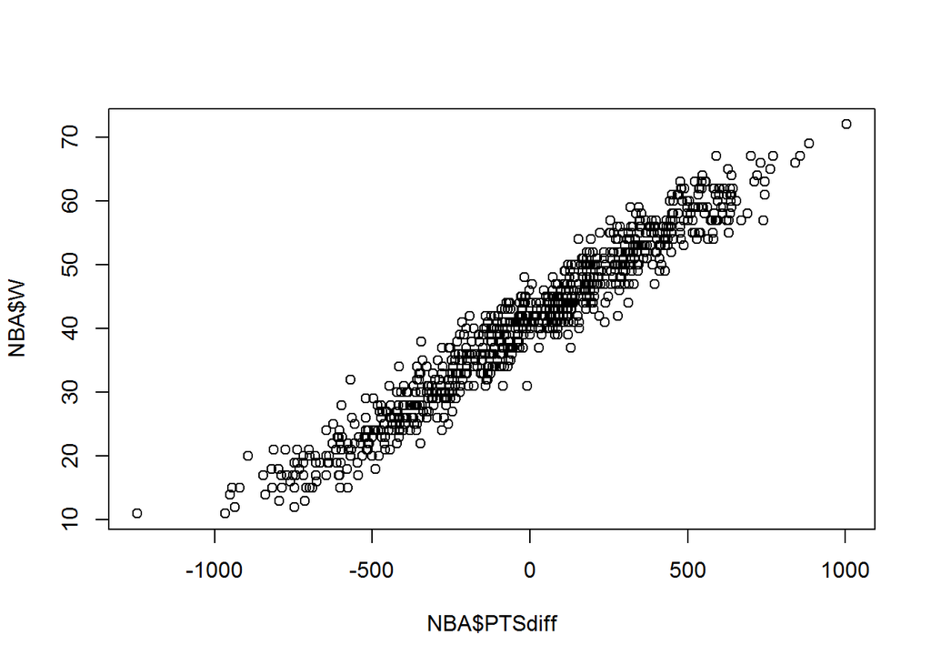

```r
# Compute Points Difference
NBA$PTSdiff<-NBA$PTS - NBA$oppPTS

# Check for linear relationship
plot(NBA$PTSdiff, NBA$W)
```

```r
# Linear regression model for wins
WinsReg = lm(W ~ PTSdiff, data=NBA)
summary(WinsReg)
```

```
##
## Call:
## lm(formula = W ~ PTSdiff, data = NBA)
##
## Residuals:
##     Min      1Q  Median      3Q     Max
## -9.7393 -2.1018 -0.0672  2.0265 10.6026
##
## Coefficients:
##              Estimate Std. Error t value Pr(>|t|)
## (Intercept) 4.100e+01  1.059e-01   387.0   <2e-16 ***
## PTSdiff     3.259e-02  2.793e-04   116.7   <2e-16 ***
## ---
## Signif. codes:  0 '***' 0.001 '**' 0.01 '*' 0.05 '.' 0.1 ' ' 1
##
## Residual standard error: 3.061 on 833 degrees of freedom
## Multiple R-squared:  0.9423, Adjusted R-squared:  0.9423
## F-statistic: 1.361e+04 on 1 and 833 DF,  p-value: < 2.2e-16
```

```r
#lets write the linear model

#W= 41 + 0.0326 * PTSdiff >= 42
#from the table the team would like to win abt 42 games to make it to the playoffs
# therefore  PTSdiff= 42-41/0.0326= 30.67 ==31
```

**VIDEO 3: POINTS SCORED**

```r
# VIDEO 3

# Linear regression model for points scored
PointsReg = lm(PTS ~ X2PA + X3PA + FTA + AST + ORB + DRB + TOV + STL + BLK, data=NBA)
summary(PointsReg)
```

```
##
## Call:
## lm(formula = PTS ~ X2PA + X3PA + FTA + AST + ORB + DRB + TOV +
##     STL + BLK, data = NBA)
##
## Residuals:
##     Min      1Q  Median      3Q     Max
## -527.40 -119.83    7.83  120.67  564.71
##
## Coefficients:
##               Estimate Std. Error t value Pr(>|t|)
## (Intercept) -2.051e+03  2.035e+02 -10.078   <2e-16 ***
## X2PA         1.043e+00  2.957e-02  35.274   <2e-16 ***
## X3PA         1.259e+00  3.843e-02  32.747   <2e-16 ***
## FTA          1.128e+00  3.373e-02  33.440   <2e-16 ***
## AST          8.858e-01  4.396e-02  20.150   <2e-16 ***
## ORB         -9.554e-01  7.792e-02 -12.261   <2e-16 ***
## DRB          3.883e-02  6.157e-02   0.631   0.5285
## TOV         -2.475e-02  6.118e-02  -0.405   0.6859
## STL         -1.992e-01  9.181e-02  -2.169   0.0303 *
## BLK         -5.576e-02  8.782e-02  -0.635   0.5256
## ---
## Signif. codes:  0 '***' 0.001 '**' 0.01 '*' 0.05 '.' 0.1 ' ' 1
##
## Residual standard error: 185.5 on 825 degrees of freedom
## Multiple R-squared:  0.8992, Adjusted R-squared:  0.8981
## F-statistic: 817.3 on 9 and 825 DF,  p-value: < 2.2e-16
```

```r
# Sum of Squared Errors
head(PointsReg$residuals)
```

```
##           1           2           3           4           5           6
##   38.572271  142.872004  -92.895718   -8.391347 -258.470561  171.460833
```

```r
SSE = sum(PointsReg$residuals^2)
SSE #difficult to interpret, hence we calc RMSE
```

```
## [1] 28394314
```

```r
# Root mean squared error
RMSE = sqrt(SSE/nrow(NBA))
RMSE
```

```
## [1] 184.4049
```

```r
# Average number of points in a season
mean(NBA$PTS)
```

```
## [1] 8370.24
```

```r
# Remove insignifcant variables
summary(PointsReg)
```

```
##
## Call:
## lm(formula = PTS ~ X2PA + X3PA + FTA + AST + ORB + DRB + TOV +
##     STL + BLK, data = NBA)
##
## Residuals:
##     Min      1Q  Median      3Q     Max
## -527.40 -119.83    7.83  120.67  564.71
##
## Coefficients:
##               Estimate Std. Error t value Pr(>|t|)
## (Intercept) -2.051e+03  2.035e+02 -10.078   <2e-16 ***
## X2PA         1.043e+00  2.957e-02  35.274   <2e-16 ***
## X3PA         1.259e+00  3.843e-02  32.747   <2e-16 ***
## FTA          1.128e+00  3.373e-02  33.440   <2e-16 ***
## AST          8.858e-01  4.396e-02  20.150   <2e-16 ***
## ORB         -9.554e-01  7.792e-02 -12.261   <2e-16 ***
## DRB          3.883e-02  6.157e-02   0.631   0.5285
## TOV         -2.475e-02  6.118e-02  -0.405   0.6859
## STL         -1.992e-01  9.181e-02  -2.169   0.0303 *
## BLK         -5.576e-02  8.782e-02  -0.635   0.5256
## ---
## Signif. codes:  0 '***' 0.001 '**' 0.01 '*' 0.05 '.' 0.1 ' ' 1
##
## Residual standard error: 185.5 on 825 degrees of freedom
## Multiple R-squared:  0.8992, Adjusted R-squared:  0.8981
## F-statistic: 817.3 on 9 and 825 DF,  p-value: < 2.2e-16
```

```r
PointsReg2 = lm(PTS ~ X2PA + X3PA + FTA + AST + ORB + DRB + STL + BLK, data=NBA) # remove var TOV as it has highest non significant p value
summary(PointsReg2)
```

```
##
## Call:
## lm(formula = PTS ~ X2PA + X3PA + FTA + AST + ORB + DRB + STL +
##     BLK, data = NBA)
##
## Residuals:
##     Min      1Q  Median      3Q     Max
## -526.79 -121.09    6.37  120.74  565.94
##
## Coefficients:
##               Estimate Std. Error t value Pr(>|t|)
## (Intercept) -2.077e+03  1.931e+02 -10.755   <2e-16 ***
## X2PA         1.044e+00  2.951e-02  35.366   <2e-16 ***
## X3PA         1.263e+00  3.703e-02  34.099   <2e-16 ***
## FTA          1.125e+00  3.308e-02  34.023   <2e-16 ***
## AST          8.861e-01  4.393e-02  20.173   <2e-16 ***
## ORB         -9.581e-01  7.758e-02 -12.350   <2e-16 ***
## DRB          3.892e-02  6.154e-02   0.632   0.5273
## STL         -2.068e-01  8.984e-02  -2.301   0.0216 *
## BLK         -5.863e-02  8.749e-02  -0.670   0.5029
## ---
## Signif. codes:  0 '***' 0.001 '**' 0.01 '*' 0.05 '.' 0.1 ' ' 1
##
## Residual standard error: 185.4 on 826 degrees of freedom
## Multiple R-squared:  0.8991, Adjusted R-squared:  0.8982
## F-statistic: 920.4 on 8 and 826 DF,  p-value: < 2.2e-16
```

```r
PointsReg3 = lm(PTS ~ X2PA + X3PA + FTA + AST + ORB + STL + BLK, data=NBA)
summary(PointsReg3)# remove var DRB as it has highest non significant p value
```

```
##
## Call:
## lm(formula = PTS ~ X2PA + X3PA + FTA + AST + ORB + STL + BLK,
##     data = NBA)
##
## Residuals:
##     Min      1Q  Median      3Q     Max
## -523.79 -121.64    6.07  120.81  573.64
##
## Coefficients:
##               Estimate Std. Error t value Pr(>|t|)
## (Intercept) -2.015e+03  1.670e+02 -12.068  < 2e-16 ***
## X2PA         1.048e+00  2.852e-02  36.753  < 2e-16 ***
## X3PA         1.271e+00  3.475e-02  36.568  < 2e-16 ***
## FTA          1.128e+00  3.270e-02  34.506  < 2e-16 ***
## AST          8.909e-01  4.326e-02  20.597  < 2e-16 ***
## ORB         -9.702e-01  7.519e-02 -12.903  < 2e-16 ***
## STL         -2.276e-01  8.356e-02  -2.724  0.00659 **
## BLK         -3.882e-02  8.165e-02  -0.475  0.63462
## ---
## Signif. codes:  0 '***' 0.001 '**' 0.01 '*' 0.05 '.' 0.1 ' ' 1
##
## Residual standard error: 185.4 on 827 degrees of freedom
## Multiple R-squared:  0.8991, Adjusted R-squared:  0.8982
## F-statistic:  1053 on 7 and 827 DF,  p-value: < 2.2e-16
```

```r
PointsReg4 = lm(PTS ~ X2PA + X3PA + FTA + AST + ORB + STL, data=NBA)
summary(PointsReg4)# remove var BLK as it has highest non significant p
```

```
##
## Call:
## lm(formula = PTS ~ X2PA + X3PA + FTA + AST + ORB + STL, data = NBA)
##
## Residuals:
##     Min      1Q  Median      3Q     Max
## -523.33 -122.02    6.93  120.68  568.26
##
## Coefficients:
##               Estimate Std. Error t value Pr(>|t|)
## (Intercept) -2.033e+03  1.629e+02 -12.475  < 2e-16 ***
## X2PA         1.050e+00  2.829e-02  37.117  < 2e-16 ***
## X3PA         1.273e+00  3.441e-02  37.001  < 2e-16 ***
## FTA          1.127e+00  3.260e-02  34.581  < 2e-16 ***
## AST          8.884e-01  4.292e-02  20.701  < 2e-16 ***
## ORB         -9.743e-01  7.465e-02 -13.051  < 2e-16 ***
## STL         -2.268e-01  8.350e-02  -2.717  0.00673 **
## ---
## Signif. codes:  0 '***' 0.001 '**' 0.01 '*' 0.05 '.' 0.1 ' ' 1
##
## Residual standard error: 185.3 on 828 degrees of freedom
## Multiple R-squared:  0.8991, Adjusted R-squared:  0.8983
## F-statistic:  1229 on 6 and 828 DF,  p-value: < 2.2e-16
```

```r
# now we have a simple model with all significant var

# Compute SSE and RMSE for new model
SSE_4 = sum(PointsReg4$residuals^2)
RMSE_4 = sqrt(SSE_4/nrow(NBA))
SSE_4 #difficult to interpret, hence we calc RMSE
```

```
## [1] 28421465
```

```r
RMSE_4
```

```
## [1] 184.493
```

```r
# Now we hav a simpler model with almost same RMSE
```

**VIDEO 4: MAKING PREDICTIONS**

```r
# VIDEO 4

# Read in test set
NBA_test = read.csv("NBA_test.csv")

# Make predictions on test set using the linear model from the training data
PointsPredictions = predict(PointsReg4, newdata=NBA_test)

# Compute out-of-sample R^2 #how well the model predicts on test data
SSE = sum((PointsPredictions - NBA_test$PTS)^2)
SST = sum((mean(NBA$PTS) - NBA_test$PTS)^2)
R2 = 1 - SSE/SST
R2
```

```
## [1] 0.8127142
```

```r
# Compute the RMSE
RMSE = sqrt(SSE/nrow(NBA_test))
RMSE
```

```
## [1] 196.3723
```

### Assignment 2: CLIMATE CHANGE

There have been many studies documenting that the average global temperature has been increasing over the last century. The consequences of a continued rise in global temperature will be dire. Rising sea levels and an increased frequency of extreme weather events will affect billions of people.

In this problem, we will attempt to study the relationship between average global temperature and several other factors.

The file climate_change.csv contains climate data from May 1983 to December 2008. The available variables include:

Year: the observation year. Month: the observation month. Temp: the difference in degrees Celsius between the average global temperature in that period and a reference value. This data comes from the Climatic Research Unit at the University of East Anglia. CO2, N2O, CH4, CFC.11, CFC.12: atmospheric concentrations of carbon dioxide (CO2), nitrous oxide (N2O), methane (CH4), trichlorofluoromethane (CCl3F; commonly referred to as CFC-11) and dichlorodifluoromethane (CCl2F2; commonly referred to as CFC-12), respectively. This data comes from the ESRL/NOAA Global Monitoring Division. CO2, N2O and CH4 are expressed in ppmv (parts per million by volume – i.e., 397 ppmv of CO2 means that CO2 constitutes 397 millionths of the total volume of the atmosphere) CFC.11 and CFC.12 are expressed in ppbv (parts per billion by volume). Aerosols: the mean stratospheric aerosol optical depth at 550 nm. This variable is linked to volcanoes, as volcanic eruptions result in new particles being added to the atmosphere, which affect how much of the sun’s energy is reflected back into space. This data is from the Godard Institute for Space Studies at NASA. TSI: the total solar irradiance (TSI) in W/m2 (the rate at which the sun’s energy is deposited per unit area). Due to sunspots and other solar phenomena, the amount of energy that is given off by the sun varies substantially with time. This data is from the SOLARIS-HEPPA project website. MEI: multivariate El Nino Southern Oscillation index (MEI), a measure of the strength of the El Nino/La Nina-Southern Oscillation (a weather effect in the Pacific Ocean that affects global temperatures). This data comes from the ESRL/NOAA Physical Sciences Division.

**PROBLEM 1.1 - CREATING OUR FIRST MODEL**

We are interested in how changes in these variables affect future temperatures, as well as how well these variables explain temperature changes so far. To do this, first read the dataset climate_change.csv into R.

Then, split the data into a training set, consisting of all the observations up to and including 2006, and a testing set consisting of the remaining years (hint: use subset). A training set refers to the data that will be used to build the model (this is the data we give to the lm() function), and a testing set refers to the data we will use to test our predictive ability.

Next, build a linear regression model to predict the dependent variable Temp, using MEI, CO2, CH4, N2O, CFC.11, CFC.12, TSI, and Aerosols as independent variables (Year and Month should NOT be used in the model). Use the training set to build the model.

```r
climate<-read.csv("climate_change.csv")
str(climate)
```

```
## 'data.frame':    308 obs. of  11 variables:
##  $ Year    : int  1983 1983 1983 1983 1983 1983 1983 1983 1984 1984 ...
##  $ Month   : int  5 6 7 8 9 10 11 12 1 2 ...
##  $ MEI     : num  2.556 2.167 1.741 1.13 0.428 ...
##  $ CO2     : num  346 346 344 342 340 ...
##  $ CH4     : num  1639 1634 1633 1631 1648 ...
##  $ N2O     : num  304 304 304 304 304 ...
##  $ CFC.11  : num  191 192 193 194 194 ...
##  $ CFC.12  : num  350 352 354 356 357 ...
##  $ TSI     : num  1366 1366 1366 1366 1366 ...
##  $ Aerosols: num  0.0863 0.0794 0.0731 0.0673 0.0619 0.0569 0.0524 0.0486 0.0451 0.0416 ...
##  $ Temp    : num  0.109 0.118 0.137 0.176 0.149 0.093 0.232 0.078 0.089 0.013 ...
```

```r
#splitting the dataset into train & test dataset

#method1
train<-subset(climate,Year<=2006)
str(train)
```

```
## 'data.frame':    284 obs. of  11 variables:
##  $ Year    : int  1983 1983 1983 1983 1983 1983 1983 1983 1984 1984 ...
##  $ Month   : int  5 6 7 8 9 10 11 12 1 2 ...
##  $ MEI     : num  2.556 2.167 1.741 1.13 0.428 ...
##  $ CO2     : num  346 346 344 342 340 ...
##  $ CH4     : num  1639 1634 1633 1631 1648 ...
##  $ N2O     : num  304 304 304 304 304 ...
##  $ CFC.11  : num  191 192 193 194 194 ...
##  $ CFC.12  : num  350 352 354 356 357 ...
##  $ TSI     : num  1366 1366 1366 1366 1366 ...
##  $ Aerosols: num  0.0863 0.0794 0.0731 0.0673 0.0619 0.0569 0.0524 0.0486 0.0451 0.0416 ...
##  $ Temp    : num  0.109 0.118 0.137 0.176 0.149 0.093 0.232 0.078 0.089 0.013 ...
```

```r
dim(train)
```

```
## [1] 284  11
```

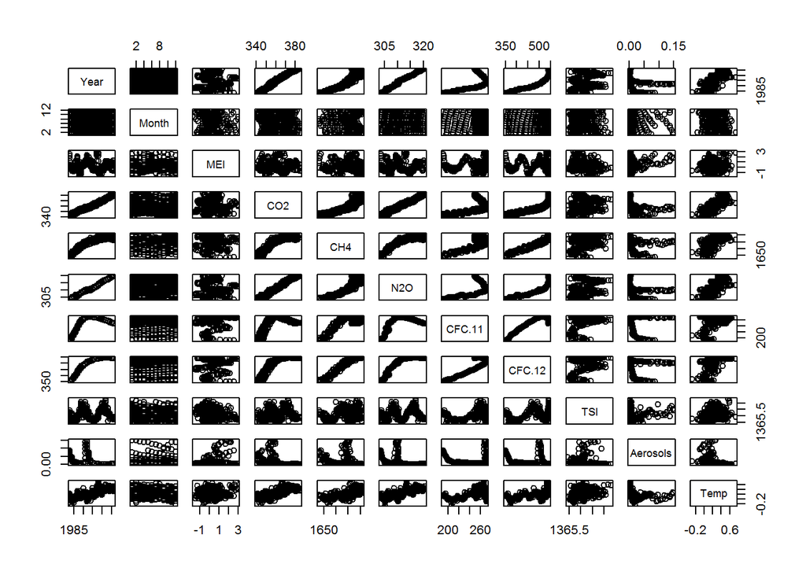

```r
plot(train) #scatter plot matrix
```

```r
test<-subset(climate,Year>2006)
str(test)
```

```
## 'data.frame':    24 obs. of  11 variables:
##  $ Year    : int  2007 2007 2007 2007 2007 2007 2007 2007 2007 2007 ...
##  $ Month   : int  1 2 3 4 5 6 7 8 9 10 ...
##  $ MEI     : num  0.974 0.51 0.074 -0.049 0.183 ...
##  $ CO2     : num  383 384 385 386 387 ...
##  $ CH4     : num  1800 1803 1803 1802 1796 ...
##  $ N2O     : num  321 321 321 321 320 ...
##  $ CFC.11  : num  248 248 248 248 247 ...
##  $ CFC.12  : num  539 539 539 539 538 ...
##  $ TSI     : num  1366 1366 1366 1366 1366 ...
##  $ Aerosols: num  0.0054 0.0051 0.0045 0.0045 0.0041 0.004 0.004 0.0041 0.0042 0.0041 ...
##  $ Temp    : num  0.601 0.498 0.435 0.466 0.372 0.382 0.394 0.358 0.402 0.362 ...
```

```r
dim(test)
```

```
## [1] 24 11
```

```r
#method2
train_index<-(climate$Year<=2006)

train1<-subset(climate,train_index)
str(train1)
```

```
## 'data.frame':    284 obs. of  11 variables:
##  $ Year    : int  1983 1983 1983 1983 1983 1983 1983 1983 1984 1984 ...
##  $ Month   : int  5 6 7 8 9 10 11 12 1 2 ...
##  $ MEI     : num  2.556 2.167 1.741 1.13 0.428 ...
##  $ CO2     : num  346 346 344 342 340 ...
##  $ CH4     : num  1639 1634 1633 1631 1648 ...
##  $ N2O     : num  304 304 304 304 304 ...
##  $ CFC.11  : num  191 192 193 194 194 ...
##  $ CFC.12  : num  350 352 354 356 357 ...
##  $ TSI     : num  1366 1366 1366 1366 1366 ...
##  $ Aerosols: num  0.0863 0.0794 0.0731 0.0673 0.0619 0.0569 0.0524 0.0486 0.0451 0.0416 ...
##  $ Temp    : num  0.109 0.118 0.137 0.176 0.149 0.093 0.232 0.078 0.089 0.013 ...
```

```r
dim(train1)
```

```
## [1] 284  11
```

```r
test1<-climate[!train_index,]
str(test1)
```

```
## 'data.frame':    24 obs. of  11 variables:
##  $ Year    : int  2007 2007 2007 2007 2007 2007 2007 2007 2007 2007 ...
##  $ Month   : int  1 2 3 4 5 6 7 8 9 10 ...
##  $ MEI     : num  0.974 0.51 0.074 -0.049 0.183 ...
##  $ CO2     : num  383 384 385 386 387 ...
##  $ CH4     : num  1800 1803 1803 1802 1796 ...
##  $ N2O     : num  321 321 321 321 320 ...
##  $ CFC.11  : num  248 248 248 248 247 ...
##  $ CFC.12  : num  539 539 539 539 538 ...
##  $ TSI     : num  1366 1366 1366 1366 1366 ...
##  $ Aerosols: num  0.0054 0.0051 0.0045 0.0045 0.0041 0.004 0.004 0.0041 0.0042 0.0041 ...
##  $ Temp    : num  0.601 0.498 0.435 0.466 0.372 0.382 0.394 0.358 0.402 0.362 ...
```

```r
dim(test1)
```

```
## [1] 24 11
```

```r
#lets now build the linear regression model on the training dataset

climatelm<-lm(Temp ~ MEI+ CO2 + CH4 + N2O + CFC.11 + CFC.12 + TSI + Aerosols, data=train)
summary(climatelm)
```

```
##
## Call:
## lm(formula = Temp ~ MEI + CO2 + CH4 + N2O + CFC.11 + CFC.12 +
##     TSI + Aerosols, data = train)
##
## Residuals:
##      Min       1Q   Median       3Q      Max
## -0.25888 -0.05913 -0.00082  0.05649  0.32433
##
## Coefficients:
##               Estimate Std. Error t value Pr(>|t|)
## (Intercept) -1.246e+02  1.989e+01  -6.265 1.43e-09 ***
## MEI          6.421e-02  6.470e-03   9.923  < 2e-16 ***
## CO2          6.457e-03  2.285e-03   2.826  0.00505 **
## CH4          1.240e-04  5.158e-04   0.240  0.81015
## N2O         -1.653e-02  8.565e-03  -1.930  0.05467 .
## CFC.11      -6.631e-03  1.626e-03  -4.078 5.96e-05 ***
## CFC.12       3.808e-03  1.014e-03   3.757  0.00021 ***
## TSI          9.314e-02  1.475e-02   6.313 1.10e-09 ***
## Aerosols    -1.538e+00  2.133e-01  -7.210 5.41e-12 ***
## ---
## Signif. codes:  0 '***' 0.001 '**' 0.01 '*' 0.05 '.' 0.1 ' ' 1
##
## Residual standard error: 0.09171 on 275 degrees of freedom
## Multiple R-squared:  0.7509, Adjusted R-squared:  0.7436
## F-statistic: 103.6 on 8 and 275 DF,  p-value: < 2.2e-16
```

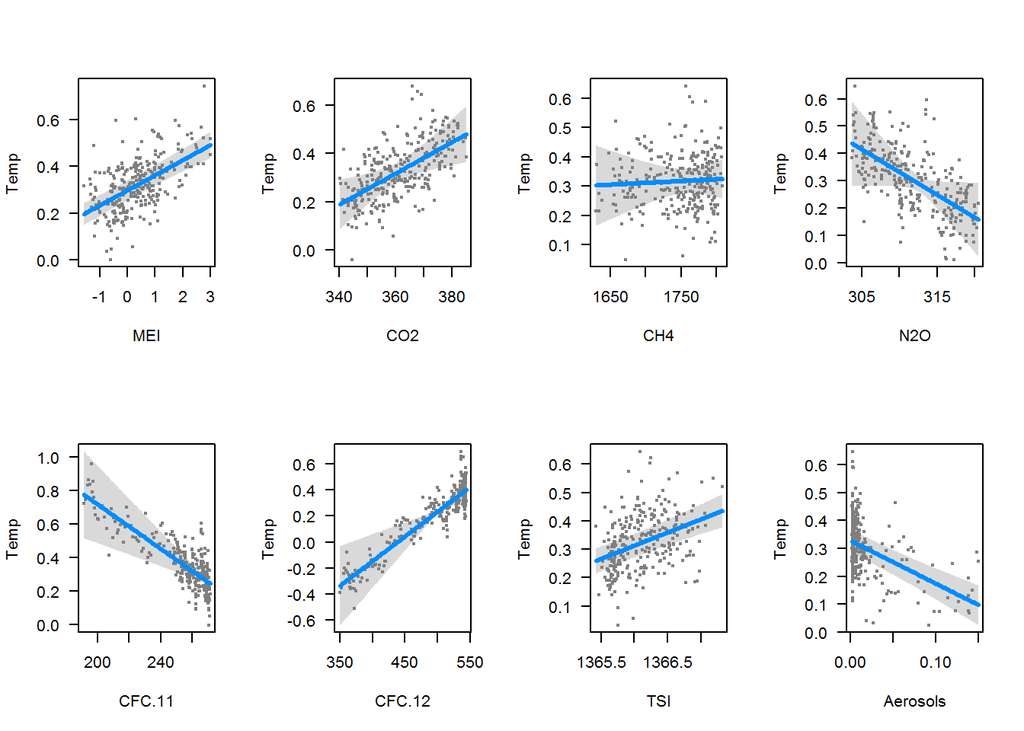

```r
#using visreg package to plot regression models.Default plots contain a confidence band, prediction line, and partial residuals.
library(visreg)
par(mfrow=c(2,4))
visreg(climatelm)
```

```r
#Enter the model R2 (the "Multiple R-squared" value):
summary(climatelm)$r.squared #?summary.lm  #to see the values that can be passed to summary()
```

```
## [1] 0.7508933
```

```r
#Ans:0.7508933

##################################

#PROBLEM 1.2 - CREATING OUR FIRST MODEL

#Q:Which variables are significant in the model? We will consider a variable signficant only if the p-value is below 0.05. (Select all that apply.)
#Ans:MEI,CO2,CFC.11,CFC.12,TSI,Aerosols  #from summary(climatelm)

####################################

#PROBLEM 2.1 - UNDERSTANDING THE MODEL

#Current scientific opinion is that nitrous oxide and CFC-11 are greenhouse gases: gases that are able to trap heat from the sun and contribute to the heating of the Earth. However, the regression coefficients of both the N2O and CFC-11 variables are negative, indicating that increasing atmospheric concentrations of either of these two compounds is associated with lower global temperatures.

#Which of the following is the simplest correct explanation for this contradiction?
#Ans:All of the gas concentration variables reflect human development - N2O and CFC.11 are correlated with other variables in the data set.
#EXPLANATION:The linear correlation of N2O and CFC.11 with other variables in the data set is quite large. The first explanation does not seem correct, as the warming effect of nitrous oxide and CFC-11 are well documented, and our regression analysis is not enough to disprove it. The second explanation is unlikely, as we have estimated eight coefficients and the intercept from 284 observations.

#############################################

#PROBLEM 2.2 - UNDERSTANDING THE MODEL

#Compute the correlations between all the variables in the training set. Which of the following independent variables is N2O highly correlated with (absolute correlation greater than 0.7)? Select all that apply.
#cor(train) # correlation matrix not required
cor(train$N2O,train)
```

```
##           Year      Month         MEI       CO2       CH4 N2O    CFC.11
## [1,] 0.9938452 0.01363153 -0.05081978 0.9767198 0.8998386   1 0.5224773
##         CFC.12       TSI   Aerosols      Temp
## [1,] 0.8679308 0.1997567 -0.3370546 0.7786389
```

```r
#Ans:CO2,CH4,CFC.12

#Which of the following independent variables is CFC.11 highly correlated with? Select all that apply.
cor(train$CFC.11,train)
```

```
##           Year       Month        MEI       CO2      CH4       N2O CFC.11
## [1,] 0.5691064 -0.01311122 0.06900044 0.5140597 0.779904 0.5224773      1
##         CFC.12      TSI   Aerosols      Temp
## [1,] 0.8689852 0.272046 -0.0439212 0.4077103
```